# SDS 4030 FINAL

Productivity Final Project

Ethan Matsubayashi & Dmitri De Freitas

```r
data <- read.table("productivity.txt", header = TRUE)
head(data)
```

|  | date | department | team | targeted_productivity | smv | over_time | incentive | idle_time | idle_men | no_of_style_change | no_of_workers | actual_productivity |
| --- | --- | --- | --- | --- | --- | --- | --- | --- | --- | --- | --- | --- |
| 1 | 1/1/2015 | sewing | 8 | 0.80 | 26.16 | 7080 | 98 | 0 | 0 | 0 | 59.0 | 0.9407254 |
| 2 | 1/1/2015 | finishing | 1 | 0.75 | 3.94 | 960 | 0 | 0 | 0 | 0 | 8.0 | 0.8865000 |
| 3 | 1/1/2015 | sewing | 11 | 0.80 | 11.41 | 3660 | 50 | 0 | 0 | 0 | 30.5 | 0.8005705 |
| 4 | 1/1/2015 | sewing | 12 | 0.80 | 11.41 | 3660 | 50 | 0 | 0 | 0 | 30.5 | 0.8005705 |
| 5 | 1/1/2015 | sewing | 6 | 0.80 | 25.90 | 1920 | 50 | 0 | 0 | 0 | 56.0 | 0.8003819 |
| 6 | 1/1/2015 | sewing | 7 | 0.80 | 25.90 | 6720 | 38 | 0 | 0 | 0 | 56.0 | 0.8001250 |

```r
summary(data)
```

```
##      date            department             team        targeted_productivity
##  Length:1160        Length:1160        Min.   : 1.000   Min.   :0.0700
##  Class :character   Class :character   1st Qu.: 4.000   1st Qu.:0.7000
##  Mode  :character   Mode  :character   Median : 7.000   Median :0.7500
##                                        Mean   : 6.545   Mean   :0.7279
##                                        3rd Qu.: 9.000   3rd Qu.:0.8000
##                                        Max.   :12.000   Max.   :0.8000
##       smv          over_time       incentive         idle_time
##  Min.   : 2.90   Min.   :    0   Min.   :   0.00   Min.   :  0.0000
##  1st Qu.: 3.94   1st Qu.: 1440   1st Qu.:   0.00   1st Qu.:  0.0000
##  Median :15.26   Median : 3960   Median :   0.00   Median :  0.0000
##  Mean   :15.01   Mean   : 4575   Mean   :  37.01   Mean   :  0.7534
##  3rd Qu.:24.26   3rd Qu.: 6960   3rd Qu.:  50.00   3rd Qu.:  0.0000
##  Max.   :54.56   Max.   :25920   Max.   :3600.00   Max.   :300.0000
##     idle_men      no_of_style_change no_of_workers   actual_productivity
##  Min.   : 0.000   Min.   :0.0000     Min.   : 2.00   Min.   :0.2337
##  1st Qu.: 0.000   1st Qu.:0.0000     1st Qu.: 9.00   1st Qu.:0.6501
##  Median : 0.000   Median :0.0000     Median :34.00   Median :0.7544
##  Mean   : 0.381   Mean   :0.1552     Mean   :34.35   Mean   :0.7260
##  3rd Qu.: 0.000   3rd Qu.:0.0000     3rd Qu.:57.00   3rd Qu.:0.8452
##  Max.   :45.000   Max.   :2.0000     Max.   :89.00   Max.   :1.0000
```

# 1: Exact & Asymptotic Tests

```r
full_model <- lm(actual_productivity ~ targeted_productivity + smv +
    over_time + incentive + idle_time + idle_men + no_of_style_change +
    no_of_workers, data = data)
summary(full_model)
```

```
##
## Call:
## lm(formula = actual_productivity ~ targeted_productivity + smv +
##     over_time + incentive + idle_time + idle_men + no_of_style_change +
##     no_of_workers, data = data)
##
## Residuals:
##      Min       1Q   Median       3Q      Max
## -0.53817 -0.06346  0.01802  0.08244  0.51019
##
## Coefficients:
##                         Estimate Std. Error t value Pr(>|t|)
## (Intercept)            2.417e-01  3.476e-02   6.954 5.94e-12 ***
## targeted_productivity  6.700e-01  4.550e-02  14.724  < 2e-16 ***
## smv                   -5.793e-03  9.659e-04  -5.997 2.68e-09 ***
## over_time             -1.949e-06  2.050e-06  -0.951 0.341935
## incentive              4.894e-05  2.703e-05   1.811 0.070466 .
## idle_time              4.687e-04  4.113e-04   1.140 0.254726
## idle_men              -8.755e-03  1.624e-03  -5.390 8.55e-08 ***
## no_of_style_change    -3.878e-02  1.154e-02  -3.360 0.000804 ***
## no_of_workers          2.903e-03  5.407e-04   5.369 9.59e-08 ***
## ---
## Signif. codes:  0 '***' 0.001 '**' 0.01 '*' 0.05 '.' 0.1 ' ' 1
##
## Residual standard error: 0.1486 on 1151 degrees of freedom
## Multiple R-squared:  0.2356, Adjusted R-squared:  0.2303
## F-statistic: 44.35 on 8 and 1151 DF,  p-value: < 2.2e-16
```

```r
red_model <- lm(actual_productivity ~ smv + no_of_workers + idle_men +
    no_of_style_change, data = data)
constraints <- c("1000*smv + 3000*no_of_workers = 3", "1000*idle_men - 300*no_of_style_change = 3")
```

## Asymptotic Wald F-Test

```r
library(car)
lh_obs = linearHypothesis(full_model, constraints, test = "F")
lh_obs
```

|  | Res.Df | RSS | Df | Sum of Sq | F | Pr(>F) |
| --- | --- | --- | --- | --- | --- | --- |
| 1 | 1153 | 25.42317 | NA | NA | NA | NA |
| 2 | 1151 | 25.42302 | 2 | 0.0001480601 | 0.003351633 | 0.996654 |

The asymptotic p value for the Wald’s F Test statistic is .9967, which means we fail to reject the null hypothesis.

## Exact Bootstrap Test

```r
n_boot = 1000

mu_hat = fitted(full_model)
sigma_hat = summary(full_model)$sigma

obs_stat <- lh_obs$F[2]
```

```r
boot_stats <- numeric(n_boot)
for (i in 1:n_boot) {
    y_boot <- mu_hat + rnorm(length(mu_hat), 0, sigma_hat)

    fit_boot <- lm(actual_productivity ~ targeted_productivity + smv +
        over_time + incentive + idle_time + idle_men + no_of_style_change +
        no_of_workers, data = within(data, actual_productivity <- y_boot))
    lh_boot <- linearHypothesis(fit_boot, constraints, test = "F")
    boot_stats[i] <- lh_boot$F[2]
}

p_value <- mean(boot_stats >= obs_stat)
cat("Bootstrap p-value:", p_value, "\n")
```

```
## Bootstrap p-value: 1
```

We test the joint null hypothesis that the two specified linear combinations of regression coefficients are equal to 3. The alternative hypothesis is that at least one of these constraints does not hold.

The Wald F test assumes linearity and homoskedasticity, which works best on a large sample size. The Bootstrap Test uses the same F-statistic, but instead of assuming the distribution, you approximate the sampling distribution by simulation rather than relying on its asymptotic form.

# 2: Standard Error Estimates & Coefficient CI’s

### Jackknife SE

```r
X = model.matrix(full_model)
n = nrow(X)
p = ncol(X)

betajack = matrix(NA, n, p)
for (i in 1:n) {
    jackfit = lm(actual_productivity ~ targeted_productivity + smv +
        over_time + incentive + idle_time + idle_men + no_of_style_change +
        no_of_workers, data = data[-i, ])
    betajack[i, ] = jackfit$coefficients
}
jackknife_se = apply(betajack, 2, sd) * sqrt((n - 1)^2/n)
print(jackknife_se)
```

```
## [1] 5.127512e-02 6.434854e-02 8.529600e-04 1.581560e-06 3.009784e-05
## [6] 7.255050e-04 1.565749e-03 8.736290e-03 4.717800e-04
```

### Nonparametric Bootstrap SE

```r
nboot = 1000
betaboot = matrix(NA, nboot, p)
for (b in 1:nboot) {
    idx = sample(1:n, replace = TRUE)
    bootfit = lm(actual_productivity ~ targeted_productivity + smv +
        over_time + incentive + idle_time + idle_men + no_of_style_change +
        no_of_workers, data = data[idx, ])
    betaboot[b, ] = bootfit$coefficients
}

bootstrap_se = apply(betaboot, 2, sd)
print(bootstrap_se)
```

```
## [1] 5.031482e-02 6.328365e-02 8.470319e-04 1.531257e-06 4.191129e-05
## [6] 4.266631e-03 1.796365e-03 8.621220e-03 4.535619e-04
```

### OLSE

```r
summary(full_model)
```

```
##
## Call:
## lm(formula = actual_productivity ~ targeted_productivity + smv +
##     over_time + incentive + idle_time + idle_men + no_of_style_change +
##     no_of_workers, data = data)
##
## Residuals:
##      Min       1Q   Median       3Q      Max
## -0.53817 -0.06346  0.01802  0.08244  0.51019
##
## Coefficients:
##                         Estimate Std. Error t value Pr(>|t|)
## (Intercept)            2.417e-01  3.476e-02   6.954 5.94e-12 ***
## targeted_productivity  6.700e-01  4.550e-02  14.724  < 2e-16 ***
## smv                   -5.793e-03  9.659e-04  -5.997 2.68e-09 ***
## over_time             -1.949e-06  2.050e-06  -0.951 0.341935
## incentive              4.894e-05  2.703e-05   1.811 0.070466 .
## idle_time              4.687e-04  4.113e-04   1.140 0.254726
## idle_men              -8.755e-03  1.624e-03  -5.390 8.55e-08 ***
## no_of_style_change    -3.878e-02  1.154e-02  -3.360 0.000804 ***
## no_of_workers          2.903e-03  5.407e-04   5.369 9.59e-08 ***
## ---
## Signif. codes:  0 '***' 0.001 '**' 0.01 '*' 0.05 '.' 0.1 ' ' 1
##
## Residual standard error: 0.1486 on 1151 degrees of freedom
## Multiple R-squared:  0.2356, Adjusted R-squared:  0.2303
## F-statistic: 44.35 on 8 and 1151 DF,  p-value: < 2.2e-16
```

```r
apply_bootstrap_CIs <- function(betaboot) {
    p = ncol(betaboot)
    nboot = nrow(betaboot)
    ci_list = vector("list", p)
    for (j in 1:p) {
        ci_percentile = quantile(betaboot[, j], c(0.025, 0.975))

        boot_mean = mean(betaboot[, j])
        boot_se = sd(betaboot[, j])
        ci_normal = boot_mean + c(-1, 1) * 1.96 * boot_se

        ci_basic = 2 * boot_mean - quantile(betaboot[, j], c(0.975, 0.025))
        ci_list[[j]] = list(Percentile = ci_percentile, Normal = ci_normal,
            Basic = ci_basic)
    }
    return(ci_list)
}

ci_list = apply_bootstrap_CIs(betaboot)
```

```r
for (j in 1:length(ci_list)) {
    cat("\nCoefficient", j, "\n")
    print(ci_list[[j]])
}
```

```
##
## Coefficient 1
## $Percentile
##      2.5%     97.5%
## 0.1463266 0.3383450
##
## $Normal
## [1] 0.1465182 0.3437523
##
## $Basic
##     97.5%      2.5%
## 0.1519254 0.3439438
##
##
## Coefficient 2
## $Percentile
##      2.5%     97.5%
## 0.5466482 0.7871797
##
## $Normal
## [1] 0.5407889 0.7888608
##
## $Basic
##     97.5%      2.5%
## 0.5424700 0.7830015
##
##
## Coefficient 3
## $Percentile
##         2.5%        97.5%
## -0.007531062 -0.004310574
##
## $Normal
## [1] -0.007468948 -0.004148583
##
## $Basic
##        97.5%         2.5%
## -0.007306956 -0.004086468
##
##
```

[output cut: 61 more lines]

```
##       97.5%        2.5%
## -0.05511854 -0.02138285
##
##
## Coefficient 9
## $Percentile
##        2.5%       97.5%
## 0.002034851 0.003780900
##
## $Normal
## [1] 0.002031159 0.003809121
##
## $Basic
##       97.5%        2.5%
## 0.002059379 0.003805429
```

The OLSE rely on homoscedasticity and normality assumptions, but jackknife and nonparametric bootstrap estimates don’t. Thus, the former two remain valid under weaker distribution assumptions.

Specifically, the coefficients for idle_time and incentive intervals are worth noting, as they both show atypical variability across resampling methods. Particularly, the bootstrap standard errors are substantially larger than both its OLS and jackknife counterparts, and the corresponding bootstrap-normal confidence interval is dramatically wider than the percentile and basic intervals. This indicates instability in the coefficient distributions. This could be caused by influential observations, skew or sparseness in the sample or collinearity with related predictors, which are amplified by the resampling of high-leverage points that nonparametric bootstrap can do.

# 3: Nonparametric Tests

```r
# Test 1: Overall statistical significance - Permutation F-test H0:
# All regression coefficients (except intercept) are zero

# Observed F-statistic from full model
f_obs <- summary(full_model)$fstatistic[1]

# Permutation test
set.seed(123)
n_perm <- 1000
f_perm <- numeric(n_perm)

for (i in 1:n_perm) {
    y_perm <- sample(data$actual_productivity)
    perm_model <- lm(y_perm ~ targeted_productivity + smv + over_time +
        incentive + idle_time + idle_men + no_of_style_change + no_of_workers,
        data = data)
    f_perm[i] <- summary(perm_model)$fstatistic[1]
}

# Permutation p-value
pval_perm_overall <- mean(f_perm >= f_obs)

# Theoretical p-value from F-distribution
pval_theoretical_overall <- pf(f_obs, summary(full_model)$fstatistic[2],
    summary(full_model)$fstatistic[3], lower.tail = FALSE)

cat("=== Overall Significance Test ===\n")
```

```
## === Overall Significance Test ===
```

```r
cat("Observed F-statistic:", f_obs, "\n")
```

```
## Observed F-statistic: 44.35442
```

```r
cat("Permutation p-value:", pval_perm_overall, "\n")
```

```
## Permutation p-value: 0
```

```r
cat("Theoretical p-value:", pval_theoretical_overall, "\n\n")
```

```
## Theoretical p-value: 2.941087e-62
```

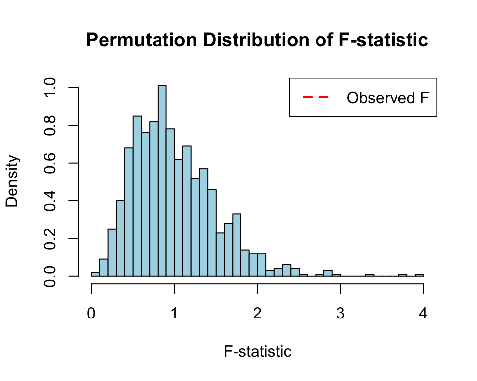

```r
# Visualize permutation distribution
hist(f_perm, breaks = 30, main = "Permutation Distribution of F-statistic",
    xlab = "F-statistic", col = "lightblue", probability = TRUE)
abline(v = f_obs, col = "red", lwd = 2, lty = 2)
legend("topright", legend = c("Observed F"), col = "red", lty = 2, lwd = 2)
```

```r
# Test 2: Single covariate test - incentive effect Permutation test
# for incentive coefficient

# Observed t-statistic for incentive
t_obs_incentive <- summary(full_model)$coefficients["incentive", "t value"]

# Permutation test for incentive
t_perm_incentive <- numeric(n_perm)

for (i in 1:n_perm) {
    # Permute the incentive variable
    data_perm <- data
    data_perm$incentive <- sample(data$incentive)

    # Fit model with permuted incentive
    perm_model_incentive <- lm(actual_productivity ~ targeted_productivity +
        smv + over_time + incentive + idle_time + idle_men + no_of_style_change +
        no_of_workers, data = data_perm)

    # Store t-statistic for incentive
    t_perm_incentive[i] <- summary(perm_model_incentive)$coefficients["incentive",
        "t value"]
}

# Permutation p-value (two-tailed)
pval_perm_incentive <- mean(abs(t_perm_incentive) >= abs(t_obs_incentive))

# Theoretical p-value from t-distribution
pval_theoretical_incentive <- summary(full_model)$coefficients["incentive",
    "Pr(>|t|)"]

cat("=== Incentive Effect Test ===\n")
```

```
## === Incentive Effect Test ===
```

```r
cat("Observed t-statistic:", t_obs_incentive, "\n")
```

```
## Observed t-statistic: 1.810583
```

```r
cat("Permutation p-value:", pval_perm_incentive, "\n")
```

```
## Permutation p-value: 0.079
```

```r
cat("Theoretical p-value:", pval_theoretical_incentive, "\n\n")
```

```
## Theoretical p-value: 0.07046613
```

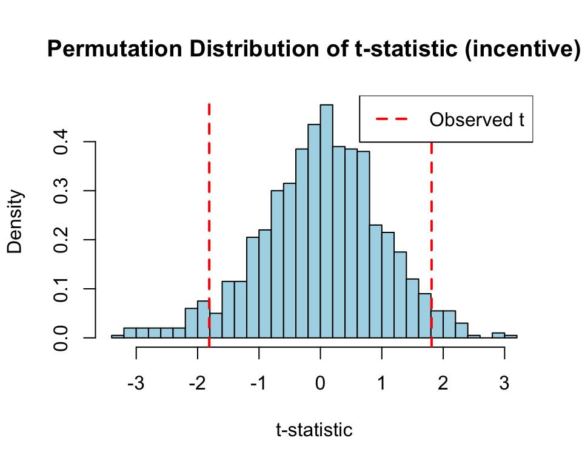

```r
# Visualize permutation distribution
hist(t_perm_incentive, breaks = 30, main = "Permutation Distribution of t-statistic (incentive)",
    xlab = "t-statistic", col = "lightblue", probability = TRUE)
abline(v = t_obs_incentive, col = "red", lwd = 2, lty = 2)
abline(v = -t_obs_incentive, col = "red", lwd = 2, lty = 2)
legend("topright", legend = c("Observed t"), col = "red", lty = 2, lwd = 2)
```

```r
# Comparison
cat("=== Comparison ===\n")
```

```
## === Comparison ===
```

```r
cat("Overall test: Permutation p-value =", pval_perm_overall, "vs Theoretical p-value =",
    pval_theoretical_overall, "\n")
```

```
## Overall test: Permutation p-value = 0 vs Theoretical p-value = 2.941087e-62
```

```r
cat("Incentive test: Permutation p-value =", pval_perm_incentive, "vs Theoretical p-value =",
    pval_theoretical_incentive, "\n\n")
```

```
## Incentive test: Permutation p-value = 0.079 vs Theoretical p-value = 0.07046613
```

```r
cat("The permutation p-values are based on the empirical null distribution.\n")
```

```
## The permutation p-values are based on the empirical null distribution.
```

```r
cat("The theoretical p-values assume F/t distributions under standard assumptions.\n")
```

```
## The theoretical p-values assume F/t distributions under standard assumptions.
```

```r
cat("Similar values suggest the theoretical assumptions are reasonable.\n")
```

```
## Similar values suggest the theoretical assumptions are reasonable.
```

## Comparison of Permutation vs Theoretical P-values

### Overall Significance Test (F-test)

- **Permutation p-value**: 0 (none of the 1,000 permutations produced an F-statistic as extreme as the observed value)
- **Theoretical p-value**: 2.94×10⁻⁶² (extremely small, essentially zero)
- **Comparison**: Both p-values are extremely small and lead to the same conclusion - we strongly reject the null hypothesis that all coefficients are zero. The permutation p-value of 0 indicates that the observed F-statistic (44.35) is far in the tail of the empirical null distribution, which aligns perfectly with the theoretical p-value.

### Incentive Effect Test (t-test)

- **Permutation p-value**: 0.079
- **Theoretical p-value**: 0.0705
- **Comparison**: The two p-values are very similar (both hovering around 0.07), suggesting close agreement between the empirical and theoretical null distributions. Both tests indicate borderline significance - the effect is marginally significant at α = 0.10 but not quite significant at α = 0.05.

### Overall Assessment

The permutation p-values closely match the theoretical p-values obtained from the F and t distributions. This agreement suggests that:

1. **The theoretical assumptions are reasonable**: The close agreement suggests that the parametric F and t reference distributions provide accurate approximations to the empirical null distributions in this setting.
2. **Large sample size validates theory**: With n = 1,160 observations, the asymptotic theory underlying the F and t distributions provides an accurate approximation to the true sampling distribution.
3. **Robustness of inference**: Since both methods lead to the same conclusions, we can be confident in our statistical inferences. The parametric tests are not misleading us due to violated assumptions.

The close correspondence between permutation-based (distribution-free) and theoretical (parametric) p-values validates our use of standard linear regression inference for this dataset.

# 4: Transformations and Model Diagnostics

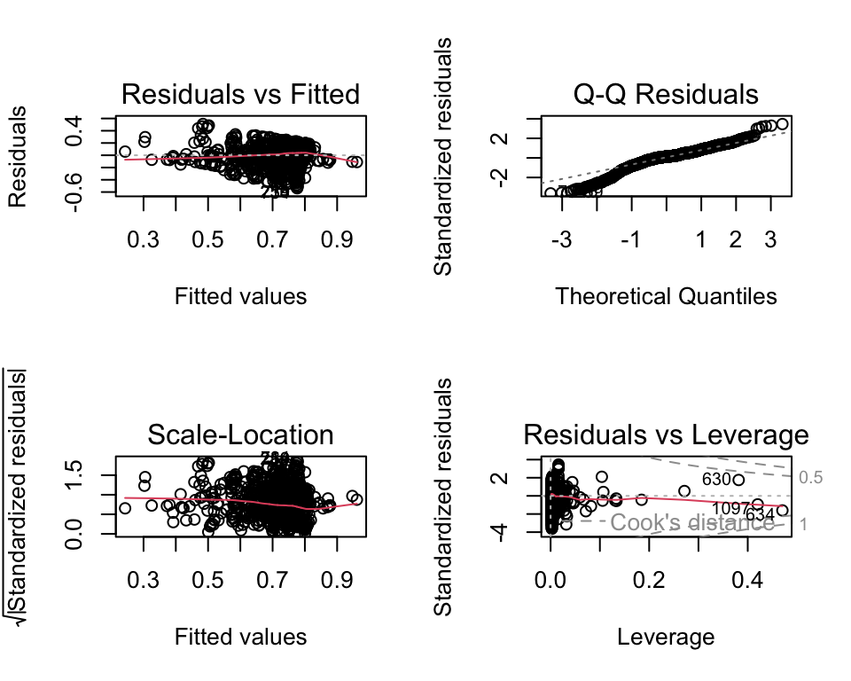

```r
par(mfrow = c(2, 2))
plot(full_model)
```

Display the four standard diagnostic plots to assess linearity, normality, constant variance, and the presence of influential observations.

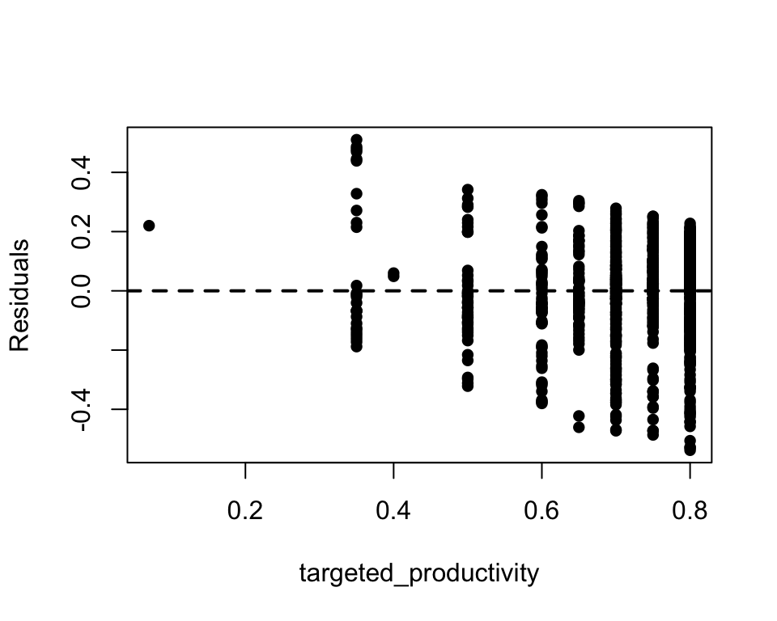

```r
plot(data$targeted_productivity, resid(full_model), xlab = "targeted_productivity",
    ylab = "Residuals", pch = 16)
abline(h = 0, lty = 2, lwd = 2)
```

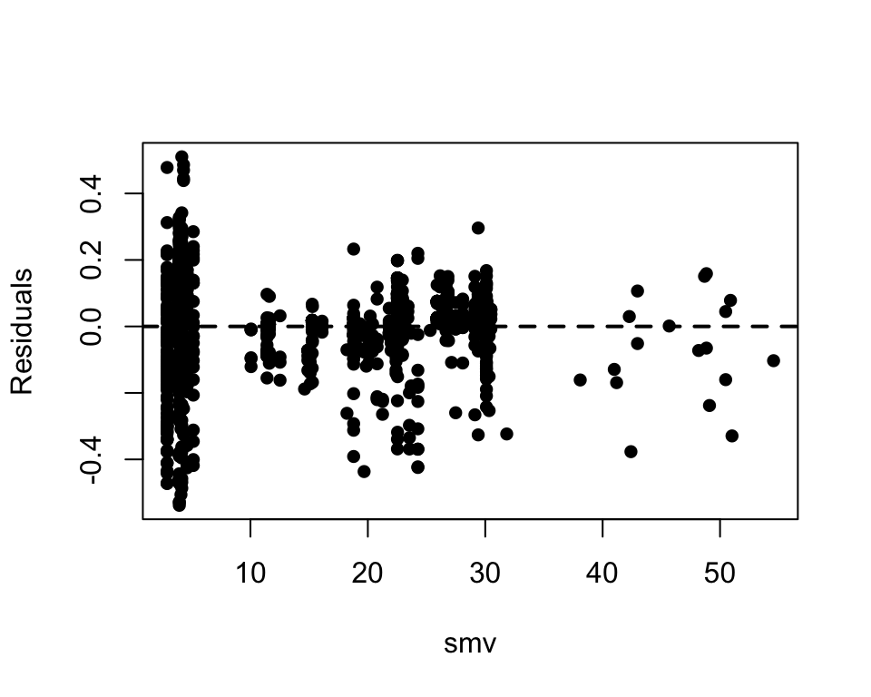

```r
plot(data$smv, resid(full_model), xlab = "smv", ylab = "Residuals", pch = 16)
abline(h = 0, lty = 2, lwd = 2)
```

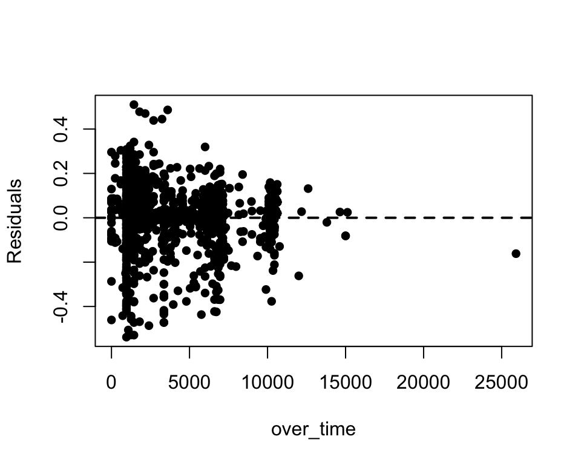

```r
plot(data$over_time, resid(full_model), xlab = "over_time", ylab = "Residuals",
    pch = 16)
abline(h = 0, lty = 2, lwd = 2)
```

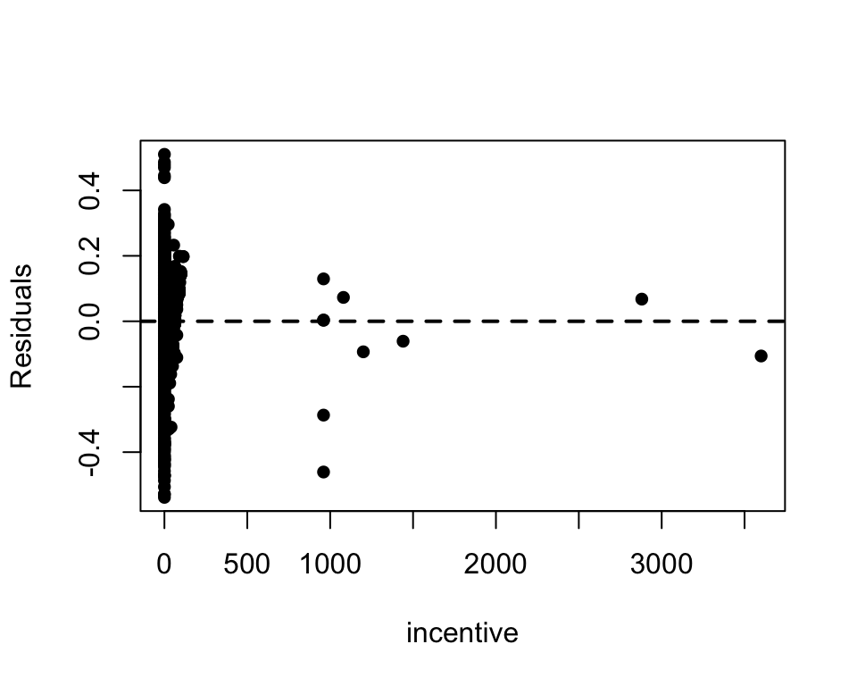

```r
plot(data$incentive, resid(full_model), xlab = "incentive", ylab = "Residuals",
    pch = 16)
abline(h = 0, lty = 2, lwd = 2)
```

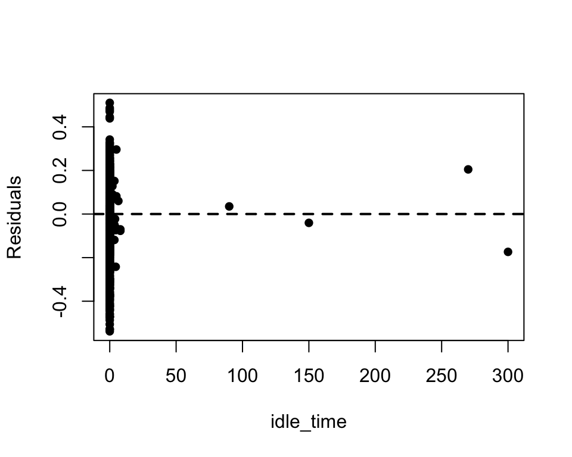

```r
plot(data$idle_time, resid(full_model), xlab = "idle_time", ylab = "Residuals",
    pch = 16)
abline(h = 0, lty = 2, lwd = 2)
```

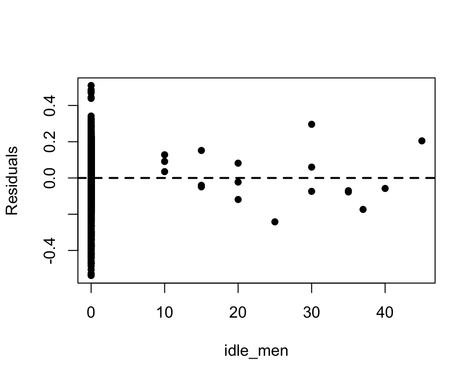

```r
plot(data$idle_men, resid(full_model), xlab = "idle_men", ylab = "Residuals",
    pch = 16)
abline(h = 0, lty = 2, lwd = 2)
```

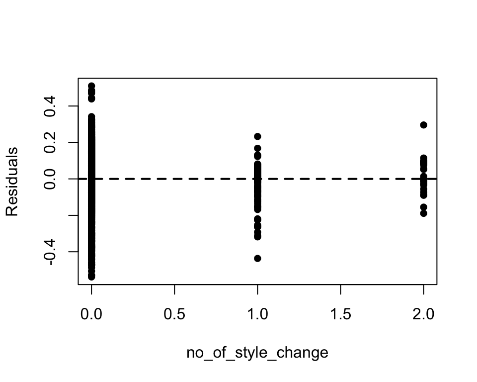

```r
plot(data$no_of_style_change, resid(full_model), xlab = "no_of_style_change",
    ylab = "Residuals", pch = 16)
abline(h = 0, lty = 2, lwd = 2)
```

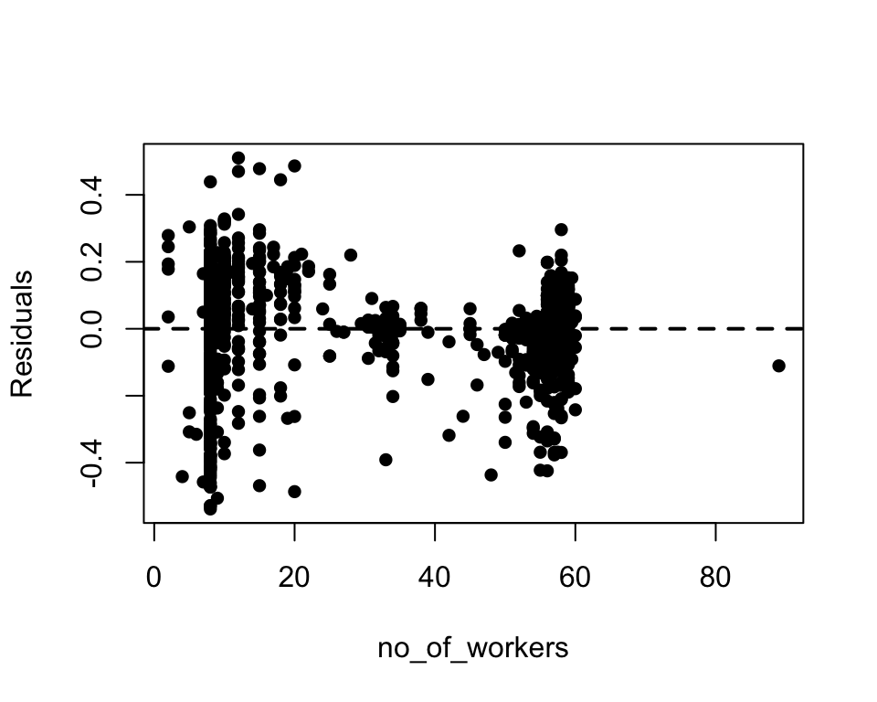

```r
plot(data$no_of_workers, resid(full_model), xlab = "no_of_workers", ylab = "Residuals",
    pch = 16)
abline(h = 0, lty = 2, lwd = 2)
```

### Standardized Residuals

```r
std_residuals <- rstandard(full_model)
```

### Histogram with Normal Curve

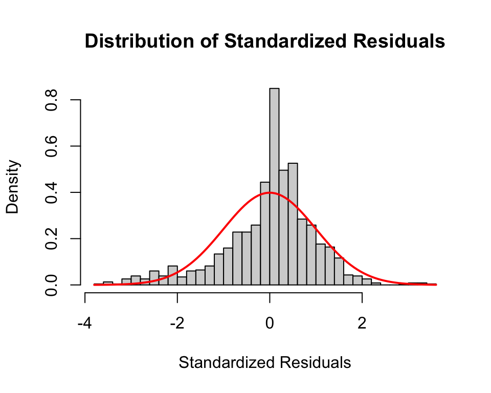

```r
hist(std_residuals, breaks = 30, prob = TRUE, main = "Distribution of Standardized Residuals",
    xlab = "Standardized Residuals")
curve(dnorm(x, mean = mean(std_residuals), sd = sd(std_residuals)), add = TRUE,
    col = "red", lwd = 2)
```

### Statistical Normality Tests

```r
shapiro.test(std_residuals)
```

```
##
##  Shapiro-Wilk normality test
##
## data:  std_residuals
## W = 0.94892, p-value < 2.2e-16
```

```
## no dparams supplied. Estimating parameters from the data...
```

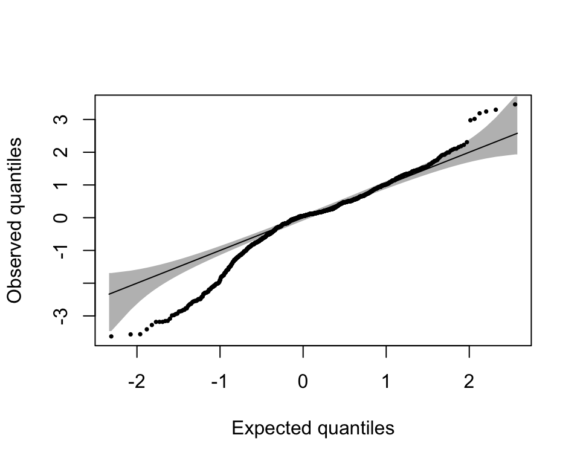

```r
library(qqconf)
qq_conf_plot(std_residuals, points_params = list(pch = 16, cex = 0.5))
```

**Assessment of Normality in Standardized Residuals:**

**Evidence and Interpretation:**

The quantile-quantile (QQ) plot displays large deviations, especially at either end, indicating violation of normality. This is evident by the 95% confidence bands on the QQ confidence plot— our observed data points clearly fall beyond the 95% confidence threshold, meaning we can reject the null hypothesis of normality at alpha = 0.05, and thus must transform our data.

### Box-Cox Response Transformation

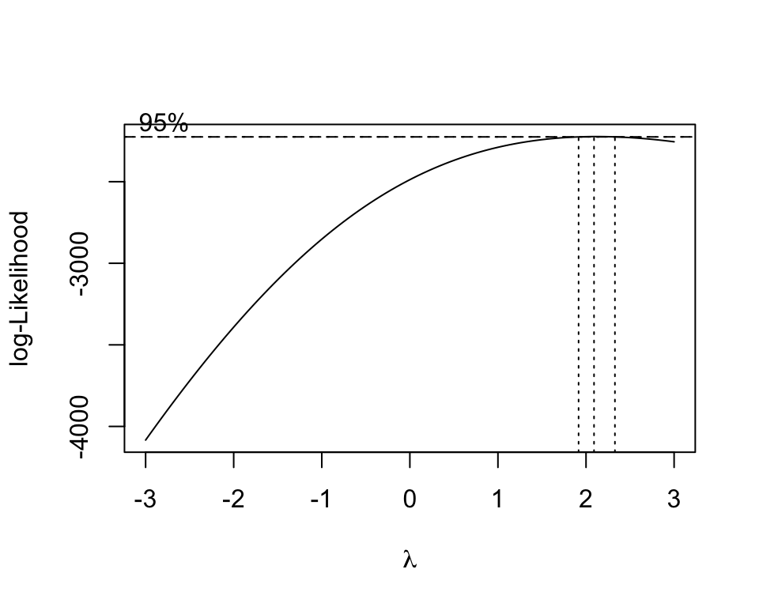

```r
library(MASS)
bc <- boxcox(full_model, lambda = seq(-3, 3, by = 0.1))
lambda_hat <- bc$x[which.max(bc$y)]
abline(h = max(bc$y) - qchisq(0.95, df = 1)/2, lty = 2)
```

The CI falls around lambda=2, which implies that a square-transformation is appropriate.

```r
sq <- lm(actual_productivity^2 ~ targeted_productivity + smv + over_time +
    incentive + idle_time + idle_men + no_of_style_change + no_of_workers,
    data = data)
summary(sq)
```

```
##
## Call:
## lm(formula = actual_productivity^2 ~ targeted_productivity +
##     smv + over_time + incentive + idle_time + idle_men + no_of_style_change +
##     no_of_workers, data = data)
##
## Residuals:
##      Min       1Q   Median       3Q      Max
## -0.57220 -0.10088  0.01063  0.11079  0.72514
##
## Coefficients:
##                         Estimate Std. Error t value Pr(>|t|)
## (Intercept)           -3.497e-02  4.606e-02  -0.759 0.447842
## targeted_productivity  8.362e-01  6.030e-02  13.868  < 2e-16 ***
## smv                   -7.745e-03  1.280e-03  -6.050 1.95e-09 ***
## over_time             -2.135e-06  2.717e-06  -0.786 0.432109
## incentive              6.452e-05  3.582e-05   1.801 0.071897 .
## idle_time              4.278e-04  5.451e-04   0.785 0.432755
## idle_men              -9.499e-03  2.153e-03  -4.413 1.12e-05 ***
## no_of_style_change    -5.673e-02  1.530e-02  -3.709 0.000218 ***
## no_of_workers          3.430e-03  7.165e-04   4.786 1.92e-06 ***
## ---
## Signif. codes:  0 '***' 0.001 '**' 0.01 '*' 0.05 '.' 0.1 ' ' 1
##
## Residual standard error: 0.197 on 1151 degrees of freedom
## Multiple R-squared:  0.2239, Adjusted R-squared:  0.2185
## F-statistic: 41.52 on 8 and 1151 DF,  p-value: < 2.2e-16
```

```
## no dparams supplied. Estimating parameters from the data...
```

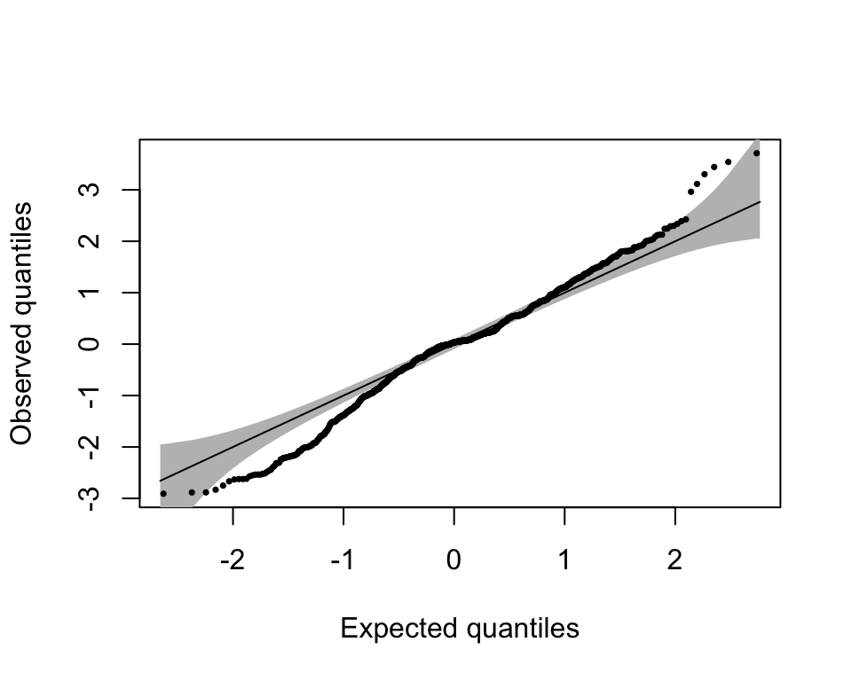

```r
sq_residuals <- rstandard(sq)
qq_conf_plot(sq_residuals, points_params = list(pch = 16, cex = 0.5))
```

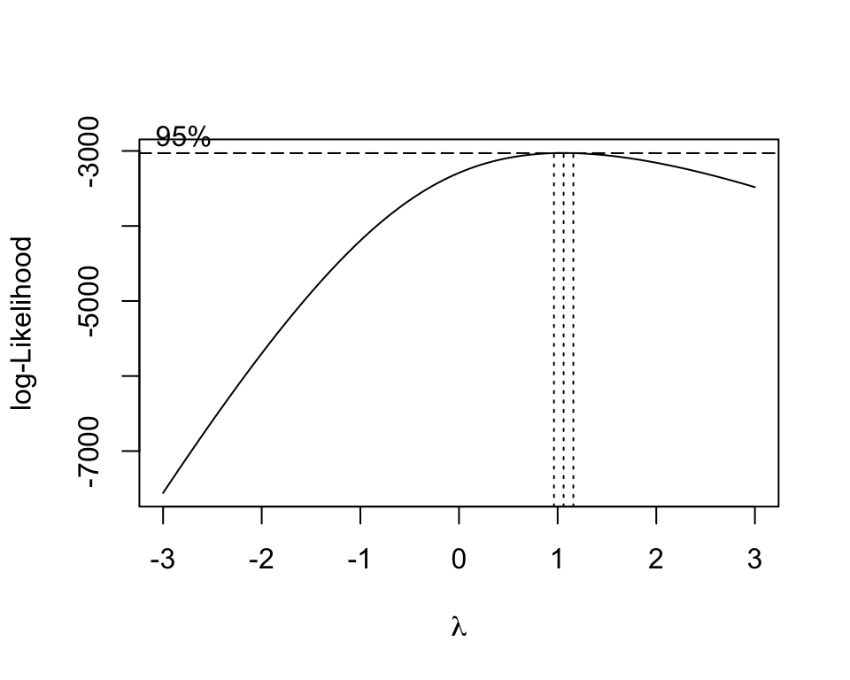

```r
bc <- boxcox(sq, lambda = seq(-3, 3, by = 0.1))
lambda_hat <- bc$x[which.max(bc$y)]
abline(h = max(bc$y) - qchisq(0.95, df = 1)/2, lty = 2)
```

### Covariate Transformation

```
## no dparams supplied. Estimating parameters from the data...
```

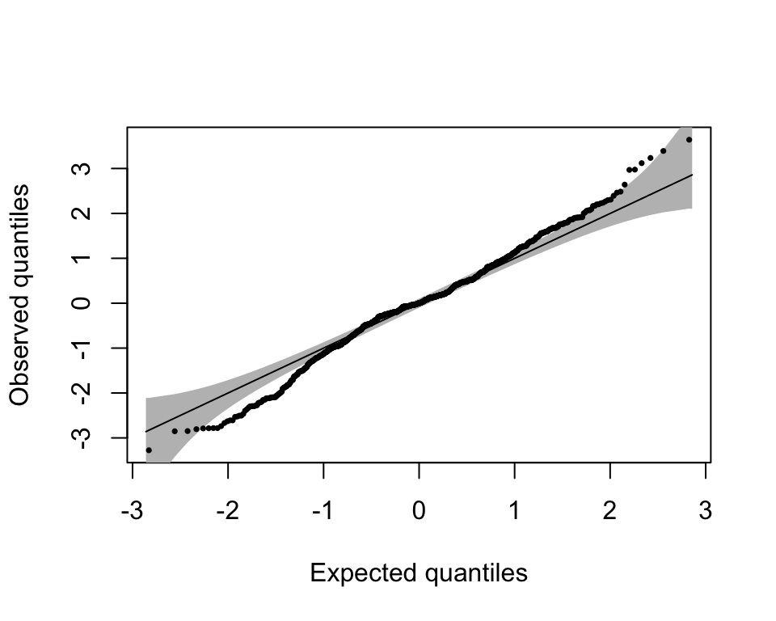

```r
data$log_smv <- log(data$smv)
data$log_over_time <- log(data$over_time + 1)
data$log_incentive <- log(data$incentive + 1)
data$log_no_of_workers <- log(data$no_of_workers + 1)
data$log_targeted_productivity <- log(data$targeted_productivity + 1)



transformed <- lm(actual_productivity^2 ~ log_targeted_productivity +
    log_smv + log_over_time + log_incentive + idle_time + idle_men +
    no_of_style_change + log_no_of_workers, data = data)

transformed_residuals <- rstandard(transformed)
qq_conf_plot(transformed_residuals, points_params = list(pch = 16, cex = 0.5))
```

```r
summary(transformed)
```

```
##
## Call:
## lm(formula = actual_productivity^2 ~ log_targeted_productivity +
##     log_smv + log_over_time + log_incentive + idle_time + idle_men +
##     no_of_style_change + log_no_of_workers, data = data)
##
## Residuals:
##      Min       1Q   Median       3Q      Max
## -0.62300 -0.09717 -0.00013  0.10611  0.70193
##
## Coefficients:
##                             Estimate Std. Error t value Pr(>|t|)
## (Intercept)               -0.0998636  0.0700675  -1.425 0.154356
## log_targeted_productivity  1.1802359  0.0973028  12.130  < 2e-16 ***
## log_smv                   -0.1412163  0.0198213  -7.124 1.84e-12 ***
## log_over_time              0.0018946  0.0046062   0.411 0.680918
## log_incentive              0.0299274  0.0046233   6.473 1.42e-10 ***
## idle_time                  0.0004054  0.0005412   0.749 0.454000
## idle_men                  -0.0069572  0.0022077  -3.151 0.001668 **
## no_of_style_change        -0.0438084  0.0146467  -2.991 0.002840 **
## log_no_of_workers          0.0856584  0.0223594   3.831 0.000135 ***
## ---
## Signif. codes:  0 '***' 0.001 '**' 0.01 '*' 0.05 '.' 0.1 ' ' 1
##
## Residual standard error: 0.1945 on 1151 degrees of freedom
## Multiple R-squared:  0.2434, Adjusted R-squared:  0.2381
## F-statistic: 46.28 on 8 and 1151 DF,  p-value: < 2.2e-16
```

Summary of results:

Initial diagnostics revealed violations of linearity, constant variance, and normality assumptions in the original model.

Despite statistical rejection of normality, the large sample size (n = 1,160) makes even minor deviations statistically significant. The transformations have substantially improved model assumptions, making the final model suitable for inference.

```
## no dparams supplied. Estimating parameters from the data...
```

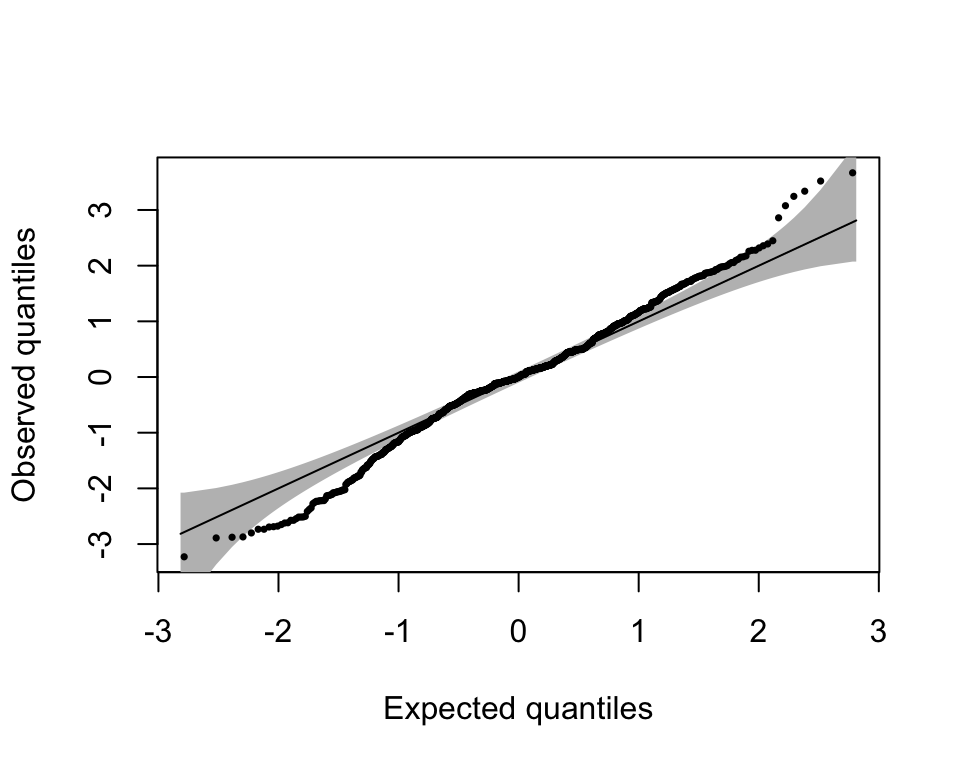

```r
library(qqconf)
library(MASS)
library(car)
library(glmnet)
library(lme4)


data$log_over_time <- log1p(data$over_time)
data$log_incentive <- log1p(data$incentive)
data$log_idle_time <- log1p(data$idle_time)
data$sqrt_smv <- sqrt(data$smv)
data$log_idle_men <- log1p(data$idle_men)
data$no_of_style_change <- as.factor(data$no_of_style_change)


transformed <- lm(actual_productivity^2 ~ targeted_productivity + log_over_time +
    log_incentive + log_idle_time + sqrt_smv + log_idle_men + no_of_style_change +
    no_of_workers, data = data)

transformed_residuals <- rstandard(transformed)
qq_conf_plot(transformed_residuals, points_params = list(pch = 16, cex = 0.5))
```

# 5: Model Selection

## MSPE Post Selection

```r
Y <- data$actual_productivity^2

X <- data[, c("targeted_productivity", "sqrt_smv", "log_over_time", "log_incentive",
    "log_idle_time", "log_idle_men", "no_of_style_change", "no_of_workers")]
```

```r
n = dim(X)[1]
P = dim(X)[2]
train = sample(n, 0.6 * n)
valid = sample(setdiff(1:n, train), 0.2 * n)
test = setdiff(1:n, c(train, valid))
MSPE = numeric(P)
```

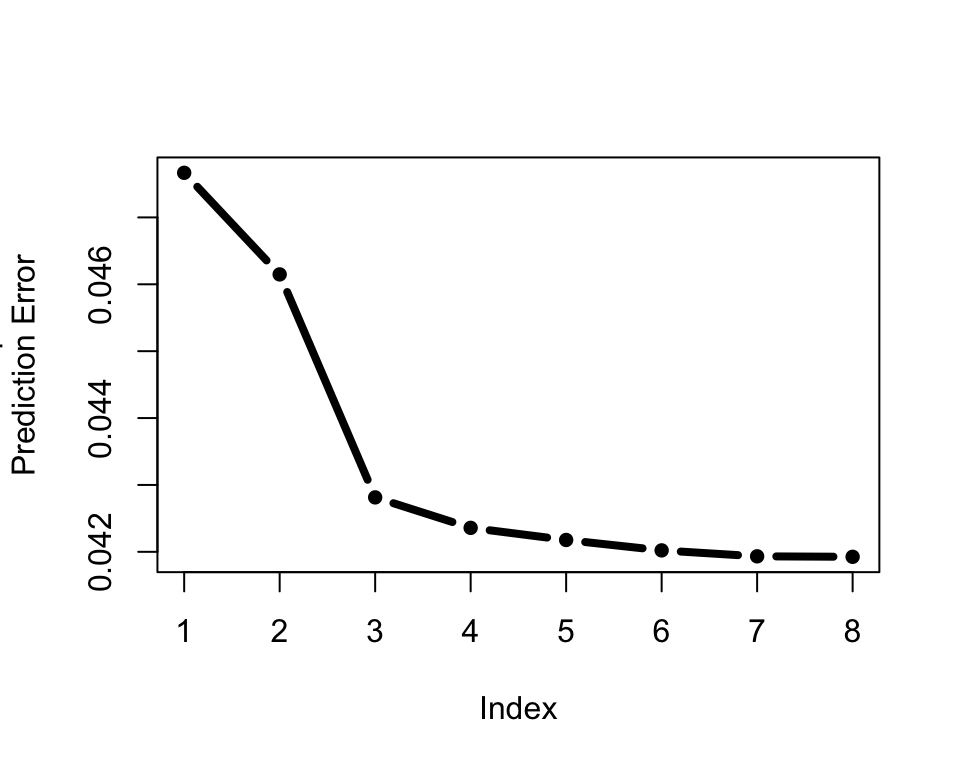

```r
for (p in P:1) {
    fit <- lm(Y[train] ~ ., data = X[train, 1:p, drop = FALSE])
    predictions <- predict(fit, newdata = X[valid, 1:p, drop = FALSE])
    MSPE[p] = mean((Y[valid] - predictions)^2)
    ind = which.max(summary(fit)$coefficients[-1, 4])
    if (ind != p) {
        X[, c(ind, p)] = X[, c(p, ind)]
        names(X)[c(ind, p)] = names(X)[c(p, ind)]
    }
}
plot(MSPE, type = "b", pch = 16, lwd = 4, ylab = "Mean Squared
Prediction Error")
```

```r
p = which.min(MSPE)
fit = lm(Y ~ ., X[, 1:p, drop = FALSE], test)
summary(fit)
```

```
##
## Call:
## lm(formula = Y ~ ., data = X[, 1:p, drop = FALSE], subset = test)
##
## Residuals:
##      Min       1Q   Median       3Q      Max
## -0.59110 -0.07774  0.00323  0.08322  0.42557
##
## Coefficients:
##                         Estimate Std. Error t value Pr(>|t|)
## (Intercept)            0.0953152  0.1374699   0.693  0.48881
## targeted_productivity  0.8586776  0.1458197   5.889 1.43e-08 ***
## sqrt_smv              -0.0494524  0.0280599  -1.762  0.07938 .
## log_incentive          0.0308433  0.0107289   2.875  0.00444 **
## log_idle_men          -0.0774449  0.0476601  -1.625  0.10559
## no_of_workers          0.0007817  0.0019083   0.410  0.68245
## log_over_time         -0.0062013  0.0093284  -0.665  0.50688
## no_of_style_change1   -0.0633507  0.0439985  -1.440  0.15132
## no_of_style_change2   -0.0723251  0.0769571  -0.940  0.34834
## log_idle_time          0.0550711  0.0594578   0.926  0.35534
## ---
## Signif. codes:  0 '***' 0.001 '**' 0.01 '*' 0.05 '.' 0.1 ' ' 1
##
## Residual standard error: 0.1849 on 222 degrees of freedom
## Multiple R-squared:  0.3123, Adjusted R-squared:  0.2844
## F-statistic:  11.2 on 9 and 222 DF,  p-value: 2.183e-14
```

# 6: Ridge Regression

```r
library(car)
vif(transformed)
```

```
##                            GVIF Df GVIF^(1/(2*Df))
## targeted_productivity  1.108723  1        1.052959
## log_over_time          1.404625  1        1.185169
## log_incentive          2.483689  1        1.575972
## log_idle_time          3.881663  1        1.970194
## sqrt_smv               9.879098  1        3.143103
## log_idle_men           4.072575  1        2.018062
## no_of_style_change     1.375320  2        1.082931
## no_of_workers         10.593026  1        3.254693
```

```r
train = c(train, valid)
X = as.matrix(X)

cv.ridge = cv.glmnet(X[train, ], Y[train], nfolds = 5, alpha = 0)

ridge = glmnet(X[train, ], Y[train], alpha = 0, lambda = cv.ridge$lambda.min)

pred = predict(ridge, newx = X[test, ], s = cv.ridge$lambda.min)
MSPE.test = mean((Y[test] - pred)^2)
MSPE.test
```

```
## [1] 0.03389248
```

```r
print(ridge$beta)
```

```
## 8 x 1 sparse Matrix of class "dgCMatrix"
##                                  s0
## targeted_productivity  0.7013080071
## sqrt_smv              -0.0529775246
## log_incentive          0.0282961574
## log_idle_men          -0.0503495274
## no_of_workers          0.0008740345
## log_over_time          0.0054148509
## no_of_style_change    -0.0355244376
## log_idle_time          0.0017631407
```

```r
nboot = 10000
P <- nrow(ridge$beta)
beta <- matrix(0, nboot, P)
colnames(beta) <- rownames(ridge$beta)


for (i in 1:nboot) {
    ind = sample(train, replace = TRUE)
    beta[i, ] = as.vector(glmnet(X[ind, ], Y[ind], alpha = 0, lambda = cv.ridge$lambda.min)$beta)
}

SE = apply(beta, 2, sd)
print(SE)
```

```
## targeted_productivity              sqrt_smv         log_incentive
##          0.0928289042          0.0072549632          0.0040678837
##          log_idle_men         no_of_workers         log_over_time
##          0.0230940404          0.0004571188          0.0047589401
##    no_of_style_change         log_idle_time
##          0.0101380334          0.0238039215
```

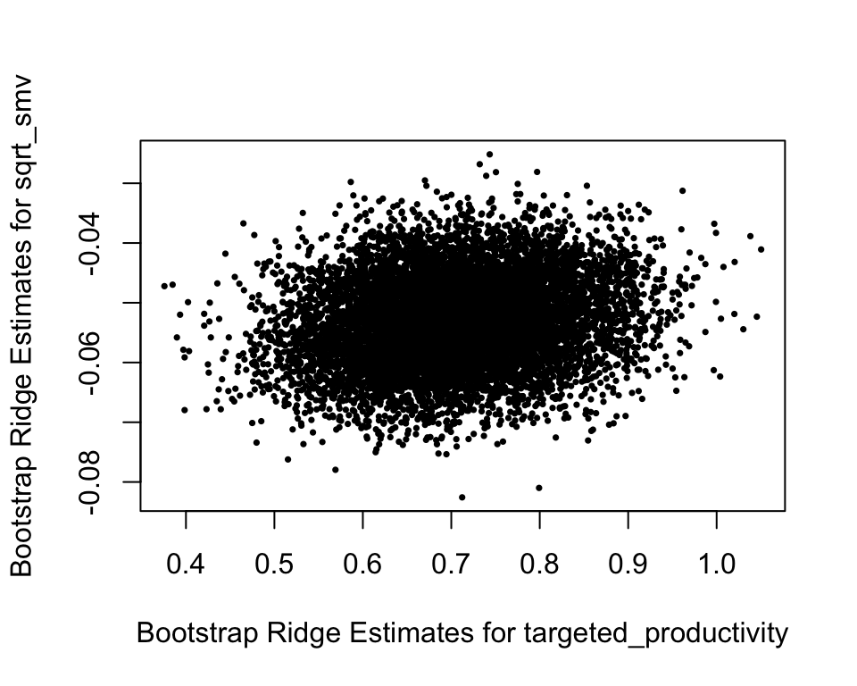

```r
plot(beta[, c("targeted_productivity", "sqrt_smv")], xlab = "Bootstrap Ridge Estimates for targeted_productivity",
    ylab = "Bootstrap Ridge Estimates for sqrt_smv", pch = 16, cex = 0.5)

abline(h = 0, lty = 2, lwd = 2)
abline(v = 0, lty = 2, lwd = 2)
```

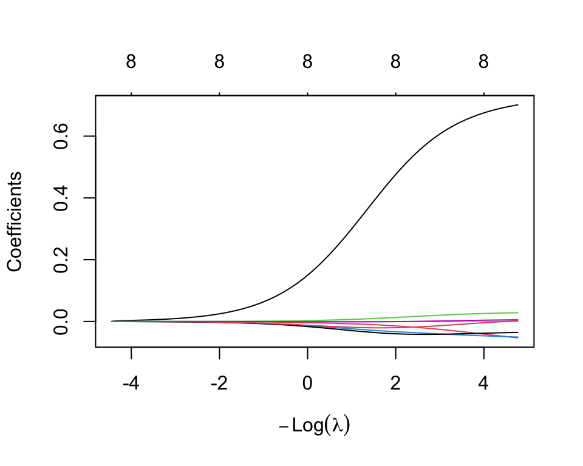

```r
ridge = glmnet(X[train, ], Y[train], alpha = 0)
plot(ridge)
```

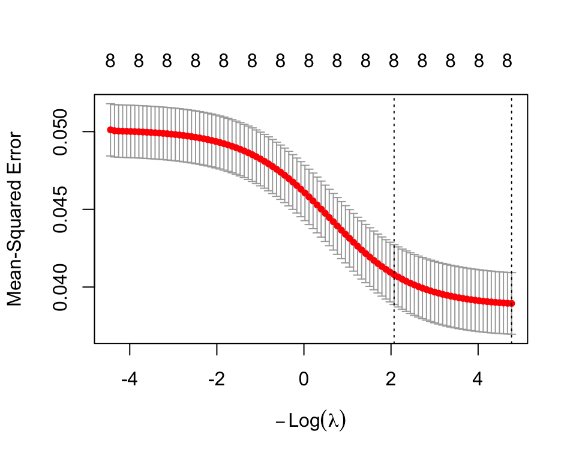

```r
cv.ridge = cv.glmnet(X[train, ], Y[train], alpha = 0, nfolds = 5)
plot(cv.ridge)
```

Takeaways:

One predictor carries most of the explanatory power

Ridge improves performance by shrinking noisy effects and stabilizing correlated coefficients.

Compared to OLS, ridge regression coefficients are biased toward zero but exhibit substantially smaller standard errors, reflecting reduced variance in the presence of multicollinearity.

# 7: Lasso Regression

```r
train = c(train, valid)
X = as.matrix(X)

cv.lasso = cv.glmnet(X[train, ], Y[train], nfolds = 5, alpha = 1)

lasso = glmnet(X[train, ], Y[train], alpha = 1, lambda = cv.lasso$lambda.min)

library(car)
vif(transformed)
```

```
##                            GVIF Df GVIF^(1/(2*Df))
## targeted_productivity  1.108723  1        1.052959
## log_over_time          1.404625  1        1.185169
## log_incentive          2.483689  1        1.575972
## log_idle_time          3.881663  1        1.970194
## sqrt_smv               9.879098  1        3.143103
## log_idle_men           4.072575  1        2.018062
## no_of_style_change     1.375320  2        1.082931
## no_of_workers         10.593026  1        3.254693
```

```r
pred = predict(lasso, newx = X[test, ], s = cv.lasso$lambda.min)
MSPE.test = mean((Y[test] - pred)^2)
MSPE.test
```

```
## [1] 0.03391206
```

```r
print(lasso$beta)
```

```
## 8 x 1 sparse Matrix of class "dgCMatrix"
##                                 s0
## targeted_productivity  0.674283635
## sqrt_smv              -0.068886022
## log_incentive          0.031583646
## log_idle_men          -0.050823973
## no_of_workers          0.001521446
## log_over_time          0.005793336
## no_of_style_change    -0.033371859
## log_idle_time          .
```

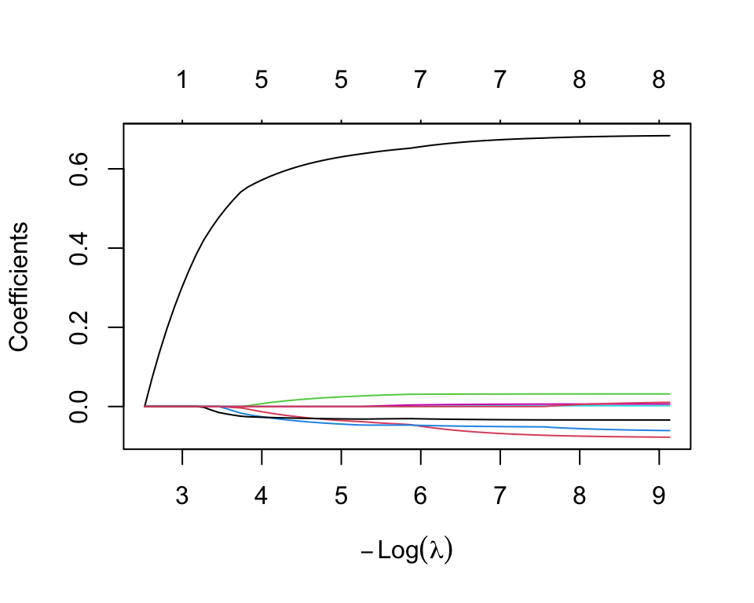

```r
plot(glmnet(X[train, ], Y[train], alpha = 1), xvar = "lambda")
```

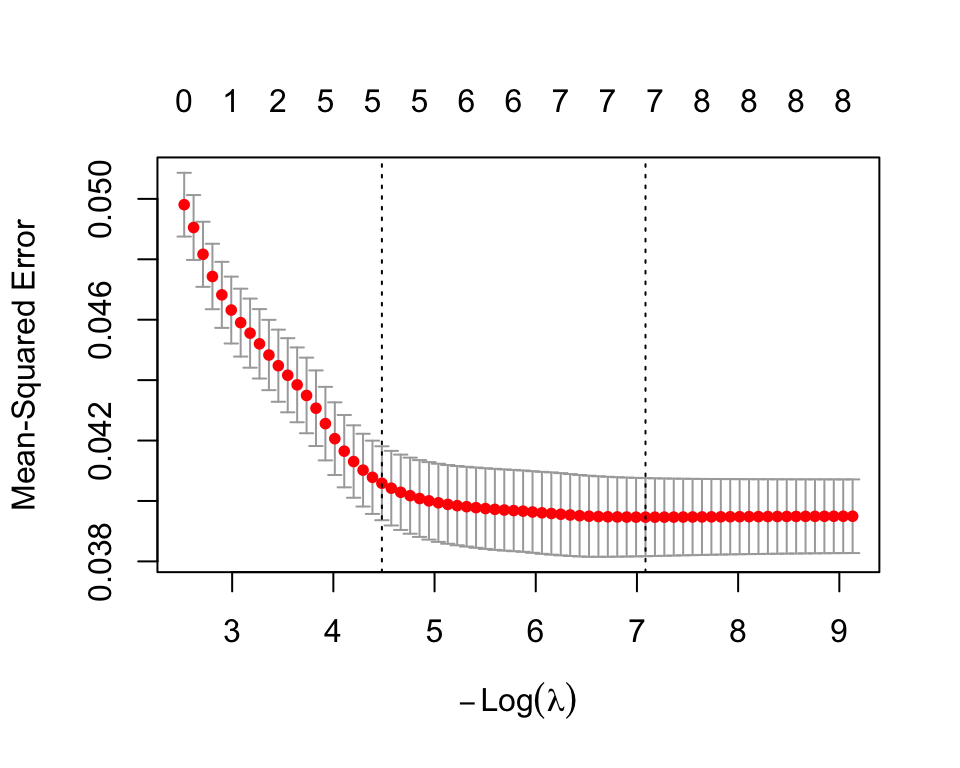

```r
plot(cv.lasso)
```

```r
nboot = 10000
P = ncol(X)

beta = matrix(0, nboot, P)
colnames(beta) = colnames(X)

for (i in 1:nboot) {
    ind = sample(train, replace = TRUE)
    beta[i, ] = as.vector(glmnet(X[ind, ], Y[ind], alpha = 1, lambda = cv.lasso$lambda.min)$beta)
}

SE = apply(beta, 2, sd)
print(SE)
```

```
## targeted_productivity              sqrt_smv         log_incentive
##          0.0868389135          0.0095507680          0.0041887182
##          log_idle_men         no_of_workers         log_over_time
##          0.0207712894          0.0006366656          0.0044184210
##    no_of_style_change         log_idle_time
##          0.0097058484          0.0224910731
```

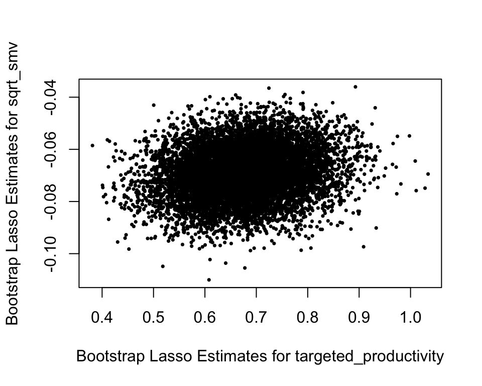

```r
plot(beta[, 1:2], xlab = paste("Bootstrap Lasso Estimates for", colnames(X)[1]),
    ylab = paste("Bootstrap Lasso Estimates for", colnames(X)[2]), pch = 16,
    cex = 0.5)
abline(h = 0, lty = 2, lwd = 2)
abline(v = 0, lty = 2, lwd = 2)
```

The lasso regression exhibits uneven shrinkage, with multiple coefficients going close to zero. The coefficient paths and cross-validation results show that only a small subset of predictors—most notably targeted_productivity—retain meaningful magnitude, while others are heavily reduced.

# 8: Interaction Effects

Investigate the interaction effects between team and all available quantitative covariates on the response variable.

```r
fit = lm(actual_productivity^2 ~ team * (targeted_productivity + sqrt_smv +
    log_over_time + log_incentive + log_idle_time + log_idle_men + no_of_style_change +
    no_of_workers), data = data)
summary(fit)
```

```
##
## Call:
## lm(formula = actual_productivity^2 ~ team * (targeted_productivity +
##     sqrt_smv + log_over_time + log_incentive + log_idle_time +
##     log_idle_men + no_of_style_change + no_of_workers), data = data)
##
## Residuals:
##      Min       1Q   Median       3Q      Max
## -0.61865 -0.09320  0.00053  0.10065  0.75724
##
## Coefficients:
##                              Estimate Std. Error t value Pr(>|t|)
## (Intercept)                 0.5195000  0.1331217   3.902 0.000101 ***
## team                       -0.0593846  0.0181011  -3.281 0.001067 **
## targeted_productivity       0.5154926  0.1381737   3.731 0.000200 ***
## sqrt_smv                   -0.1544591  0.0302906  -5.099 3.99e-07 ***
## log_over_time               0.0021889  0.0098500   0.222 0.824177
## log_incentive               0.0312912  0.0108302   2.889 0.003934 **
## log_idle_time               0.0675682  0.1176862   0.574 0.565987
## log_idle_men               -0.0957398  0.1009279  -0.949 0.343027
## no_of_style_change1        -0.0576778  0.0507223  -1.137 0.255723
## no_of_style_change2        -0.1098388  0.0849924  -1.292 0.196502
## no_of_workers               0.0064088  0.0021393   2.996 0.002797 **
## team:targeted_productivity  0.0387469  0.0194476   1.992 0.046568 *
## team:sqrt_smv               0.0107853  0.0038027   2.836 0.004645 **
## team:log_over_time         -0.0000489  0.0012614  -0.039 0.969086
## team:log_incentive          0.0002024  0.0014862   0.136 0.891690
## team:log_idle_time         -0.0073883  0.0182344  -0.405 0.685417
## team:log_idle_men           0.0048421  0.0144333   0.335 0.737325
## team:no_of_style_change1    0.0020282  0.0079857   0.254 0.799561
## team:no_of_style_change2    0.0098325  0.0105717   0.930 0.352531
## team:no_of_workers         -0.0005510  0.0002591  -2.126 0.033686 *
## ---
## Signif. codes:  0 '***' 0.001 '**' 0.01 '*' 0.05 '.' 0.1 ' ' 1
##
## Residual standard error: 0.1897 on 1140 degrees of freedom
## Multiple R-squared:  0.2871, Adjusted R-squared:  0.2752
## F-statistic: 24.16 on 19 and 1140 DF,  p-value: < 2.2e-16
```

```r
anova(fit)
```

|  | Df | Sum Sq | Mean Sq | F value | Pr(>F) |
| --- | --- | --- | --- | --- | --- |
| team | 1 | 0.680528943 | 0.680528943 | 18.91530010 | 1.488769e-05 |
| targeted_productivity | 1 | 9.478728697 | 9.478728697 | 263.46123832 | 1.847262e-53 |
| sqrt_smv | 1 | 1.031827941 | 1.031827941 | 28.67965482 | 1.032303e-07 |
| log_over_time | 1 | 0.018793465 | 0.018793465 | 0.52236431 | 4.699831e-01 |
| log_incentive | 1 | 3.981809095 | 3.981809095 | 110.67437295 | 9.112771e-25 |
| log_idle_time | 1 | 0.115271033 | 0.115271033 | 3.20395806 | 7.372561e-02 |
| log_idle_men | 1 | 0.160433052 | 0.160433052 | 4.45923625 | 3.493015e-02 |
| no_of_style_change | 2 | 0.219964253 | 0.109982126 | 3.05695290 | 4.741651e-02 |
| no_of_workers | 1 | 0.231452738 | 0.231452738 | 6.43322822 | 1.133304e-02 |
| team:targeted_productivity | 1 | 0.136535642 | 0.136535642 | 3.79500781 | 5.165078e-02 |

[output cut: 8 more lines]

```r
drop1(fit, test = "F")
```

|  | Df | Sum of Sq | RSS | AIC | F value | Pr(>F) |
| --- | --- | --- | --- | --- | --- | --- |
|  | NA | NA | 41.01457 | -3837.007 | NA | NA |
| team:targeted_productivity | 1 | 1.428150e-01 | 41.15739 | -3834.975 | 3.969543240 | 0.046568493 |
| team:sqrt_smv | 1 | 2.894168e-01 | 41.30399 | -3830.851 | 8.044340124 | 0.004645357 |
| team:log_over_time | 1 | 5.406099e-05 | 41.01463 | -3839.006 | 0.001502625 | 0.969085566 |
| team:log_incentive | 1 | 6.673666e-04 | 41.01524 | -3838.989 | 0.018549454 | 0.891690083 |
| team:log_idle_time | 1 | 5.906657e-03 | 41.02048 | -3838.840 | 0.164175514 | 0.685416981 |
| team:log_idle_men | 1 | 4.049160e-03 | 41.01862 | -3838.893 | 0.112546391 | 0.737325249 |
| team:no_of_style_change | 2 | 3.161814e-02 | 41.04619 | -3840.114 | 0.439413120 | 0.644523603 |
| team:no_of_workers | 1 | 1.626734e-01 | 41.17725 | -3834.416 | 4.521507289 | 0.033685695 |

```r
final_model <- lm(actual_productivity^2 ~ team + targeted_productivity +
    sqrt_smv + log_over_time + log_incentive + log_idle_time + log_idle_men +
    no_of_style_change + no_of_workers + team:targeted_productivity +
    team:sqrt_smv + team:no_of_workers, data = data)

summary(final_model)
```

```
##
## Call:
## lm(formula = actual_productivity^2 ~ team + targeted_productivity +
##     sqrt_smv + log_over_time + log_incentive + log_idle_time +
##     log_idle_men + no_of_style_change + no_of_workers + team:targeted_productivity +
##     team:sqrt_smv + team:no_of_workers, data = data)
##
## Residuals:
##      Min       1Q   Median       3Q      Max
## -0.61607 -0.09664  0.00250  0.10050  0.75630
##
## Coefficients:
##                              Estimate Std. Error t value Pr(>|t|)
## (Intercept)                 0.5132985  0.1123513   4.569 5.44e-06 ***
## team                       -0.0581042  0.0148430  -3.915 9.59e-05 ***
## targeted_productivity       0.5304315  0.1308676   4.053 5.39e-05 ***
## sqrt_smv                   -0.1544558  0.0296371  -5.212 2.22e-07 ***
## log_over_time               0.0016858  0.0044677   0.377  0.70600
## log_incentive               0.0324001  0.0044221   7.327 4.43e-13 ***
## log_idle_time               0.0217065  0.0307239   0.707  0.48002
## log_idle_men               -0.0647799  0.0287247  -2.255  0.02431 *
## no_of_style_change1        -0.0454550  0.0213472  -2.129  0.03344 *
## no_of_style_change2        -0.0381731  0.0358314  -1.065  0.28694
## no_of_workers               0.0062415  0.0020164   3.095  0.00201 **
## team:targeted_productivity  0.0368247  0.0183348   2.008  0.04483 *
## team:sqrt_smv               0.0104995  0.0036473   2.879  0.00407 **
## team:no_of_workers         -0.0005038  0.0002383  -2.114  0.03470 *
## ---
## Signif. codes:  0 '***' 0.001 '**' 0.01 '*' 0.05 '.' 0.1 ' ' 1
##
## Residual standard error: 0.1893 on 1146 degrees of freedom
## Multiple R-squared:  0.2864, Adjusted R-squared:  0.2783
## F-statistic: 35.38 on 13 and 1146 DF,  p-value: < 2.2e-16
```

### **Final Model Coefficient Interpretation**

**Intercept**: Expected value of the squared response when all quantitative covariates are zero.

**Main effects (targeted_productivity, sqrt_smv, log_incentive, log_idle_time, log_idle_men, no_of_style_change, no_of_workers)**: These represent the effects of each predictor for the reference team.

**team × targeted_productivity**: The effect of targeted productivity on actual productivty differs by team, implying that certain teams are better at achieving their productivity goals.

**team × sqrt_smv**: The impact of SMV on the response varies by team.

**team × no_of_workers**: The effect of the number of workers on productivity varies by team.

# 9: Mixed Effects Model

```r
data$team <- factor(data$team)
data$department <- factor(data$department)

data$date <- as.Date(data$date, format = "%m/%d/%Y")
data$date_f <- factor(data$date)

data$log_over_time <- log1p(data$over_time)
data$log_incentive <- log1p(data$incentive)
data$log_idle_time <- log1p(data$idle_time)
data$sqrt_smv <- sqrt(data$smv)
data$log_idle_men <- log1p(data$idle_men)


data$y <- data$actual_productivity^2
```

```r
fit = lmer(y ~ targeted_productivity + sqrt_smv + log_over_time + log_incentive +
    log_idle_time + log_idle_men + no_of_style_change + no_of_workers +
    (1 | team) + (1 | department) + (1 | date_f), data)

sigma = data.frame(summary(fit)$varcor)$sdcor
names(sigma) = data.frame(summary(fit)$varcor)$grp

ICC = sigma^2/sum(sigma^2)
print(ICC)
```

```
##     date_f       team department   Residual
## 0.02568207 0.03025946 0.42085679 0.52320167
```

```r
summary(fit, correlation = FALSE)
```

```
## Linear mixed model fit by REML ['lmerMod']
## Formula:
## y ~ targeted_productivity + sqrt_smv + log_over_time + log_incentive +
##     log_idle_time + log_idle_men + no_of_style_change + no_of_workers +
##     (1 | team) + (1 | department) + (1 | date_f)
##    Data: data
##
## REML criterion at convergence: -536
##
## Scaled residuals:
##     Min      1Q  Median      3Q     Max
## -3.3059 -0.5011  0.0387  0.5724  3.7916
##
## Random effects:
##  Groups     Name        Variance Std.Dev.
##  date_f     (Intercept) 0.001621 0.04027
##  team       (Intercept) 0.001911 0.04371
##  department (Intercept) 0.026572 0.16301
##  Residual               0.033034 0.18175
## Number of obs: 1160, groups:  date_f, 59; team, 12; department, 2
##
## Fixed effects:
##                        Estimate Std. Error t value
## (Intercept)           -0.028076   0.133695  -0.210
## targeted_productivity  0.712109   0.059590  11.950
## sqrt_smv              -0.061429   0.012675  -4.846
## log_over_time          0.006174   0.004520   1.366
## log_incentive          0.043796   0.004967   8.817
## log_idle_time          0.009846   0.030219   0.326
## log_idle_men          -0.041949   0.028095  -1.493
## no_of_style_change1   -0.023432   0.021895  -1.070
## no_of_style_change2   -0.019069   0.035810  -0.533
## no_of_workers          0.005046   0.001029   4.903
```

## Box Cox

```r
lambda = seq(0, 1, 0.01)
loglik = numeric(101)
for (i in 1:101) {
    if (lambda[i] == 0) {
        Ypower = log(Y)
    } else {
        Ypower = (Y^lambda[i] - 1)/lambda[i]
    }
    power = lmer(Ypower ~ targeted_productivity + sqrt_smv + log_over_time +
        log_incentive + log_idle_time + log_idle_men + no_of_style_change +
        no_of_workers + (1 | team) + (1 | department) + (1 | date_f),
        data, REML = FALSE)
    loglik[i] = logLik(power)[1] + (lambda[i] - 1) * sum(log(Y))
}
```

```r
alpha = 0.05
CI = range(lambda[loglik > max(loglik) - qchisq(alpha, 1, lower.tail = FALSE)/2])
print(CI)
```

```
## [1] 0.95 1.00
```

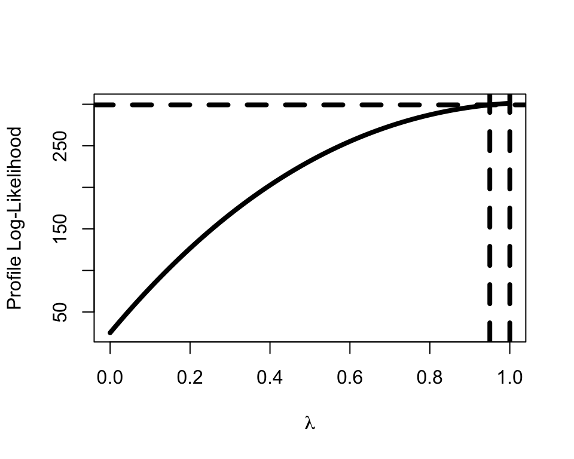

```r
plot(lambda, loglik, "l", xlab = expression(lambda), ylab = "
Profile Log-Likelihood",
    lwd = 4)
abline(h = max(loglik) - qchisq(0.95, 1)/2, lty = 2, lwd = 4)
abline(v = CI, lty = 2, lwd = 4)
```

The box-cox likelihood yields an interval of lambda=1, indicating no further transformation is needed.

## Likelihood Ratio for Fixed Effects

```r
full = lmer(y ~ targeted_productivity + sqrt_smv + log_over_time + log_incentive +
    log_idle_time + log_idle_men + no_of_style_change + no_of_workers +
    (1 | team) + (1 | department) + (1 | date_f), data, REML = FALSE)
```

```r
# targeted_productivity
reduced = lmer(y ~ sqrt_smv + log_over_time + log_incentive + log_idle_time +
    log_idle_men + no_of_style_change + no_of_workers + (1 | team) +
    (1 | department) + (1 | date_f), data, REML = FALSE)
LR = -2 * (logLik(reduced)[1] - logLik(full)[1])
pvalue = pchisq(LR, 1, lower.tail = FALSE)
print(c(targeted_productivity = pvalue))
```

```
## targeted_productivity
##           2.11687e-31
```

```r
# sqrt_smv
reduced = lmer(y ~ targeted_productivity + log_over_time + log_incentive +
    log_idle_time + log_idle_men + no_of_style_change + no_of_workers +
    (1 | team) + (1 | department) + (1 | date_f), data, REML = FALSE)
LR = -2 * (logLik(reduced)[1] - logLik(full)[1])
pvalue = pchisq(LR, 1, lower.tail = FALSE)
print(c(sqrt_smv = pvalue))
```

```
##     sqrt_smv
## 1.283029e-06
```

```r
# log_over_time
reduced = lmer(y ~ targeted_productivity + sqrt_smv + log_incentive +
    log_idle_time + log_idle_men + no_of_style_change + no_of_workers +
    (1 | team) + (1 | department) + (1 | date_f), data, REML = FALSE)
LR = -2 * (logLik(reduced)[1] - logLik(full)[1])
pvalue = pchisq(LR, 1, lower.tail = FALSE)
print(c(log_over_time = pvalue))
```

```
## log_over_time
##     0.1792079
```

```r
# log_incentive (1 df)
reduced = lmer(y ~ targeted_productivity + sqrt_smv + log_over_time +
    log_idle_time + log_idle_men + no_of_style_change + no_of_workers +
    (1 | team) + (1 | department) + (1 | date_f), data, REML = FALSE)
LR = -2 * (logLik(reduced)[1] - logLik(full)[1])
pvalue = pchisq(LR, 1, lower.tail = FALSE)
print(c(log_incentive = pvalue))
```

```
## log_incentive
##  1.102415e-16
```

```r
# log_idle_time (1 df)
reduced = lmer(y ~ targeted_productivity + sqrt_smv + log_over_time +
    log_incentive + log_idle_men + no_of_style_change + no_of_workers +
    (1 | team) + (1 | department) + (1 | date_f), data, REML = FALSE)
LR = -2 * (logLik(reduced)[1] - logLik(full)[1])
pvalue = pchisq(LR, 1, lower.tail = FALSE)
print(c(log_idle_time = pvalue))
```

```
## log_idle_time
##     0.7427418
```

```r
# log_idle_men (1 df)
reduced = lmer(y ~ targeted_productivity + sqrt_smv + log_over_time +
    log_incentive + log_idle_time + no_of_style_change + no_of_workers +
    (1 | team) + (1 | department) + (1 | date_f), data, REML = FALSE)
LR = -2 * (logLik(reduced)[1] - logLik(full)[1])
pvalue = pchisq(LR, 1, lower.tail = FALSE)
print(c(log_idle_men = pvalue))
```

```
## log_idle_men
##    0.1318879
```

```r
# no_of_workers (1 df)
reduced = lmer(y ~ targeted_productivity + sqrt_smv + log_over_time +
    log_incentive + log_idle_time + log_idle_men + no_of_style_change +
    (1 | team) + (1 | department) + (1 | date_f), data, REML = FALSE)
LR = -2 * (logLik(reduced)[1] - logLik(full)[1])
pvalue = pchisq(LR, 1, lower.tail = FALSE)
print(c(no_of_workers = pvalue))
```

```
## no_of_workers
##   4.15446e-06
```

```r
# no_of_style_change (df = number of levels - 1, since it's a
# factor)
df_style = nlevels(data$no_of_style_change) - 1

reduced = lmer(y ~ targeted_productivity + sqrt_smv + log_over_time +
    log_incentive + log_idle_time + log_idle_men + no_of_workers + (1 |
    team) + (1 | department) + (1 | date_f), data, REML = FALSE)

LR = -2 * (logLik(reduced)[1] - logLik(full)[1])
pvalue = pchisq(LR, df_style, lower.tail = FALSE)
print(c(no_of_style_change = pvalue, df = df_style))
```

```
## no_of_style_change                 df
##          0.5334465          2.0000000
```

Likelihood ratio tests indicate that targeted productivity, SMV, incentives, and team size are statistically significant fixed effects, while overtime, idle time, idle workers, and style changes do not significantly improve model fit once team-, department-, and date-level clustering is accounted for.

## ICC for Random Effects

```r
sigma = data.frame(summary(fit)$varcor)$sdcor
names(sigma) = data.frame(summary(fit)$varcor)$grp
ICC = sigma^2/sum(sigma^2)
print(ICC)
```

```
##     date_f       team department   Residual
## 0.02568207 0.03025946 0.42085679 0.52320167
```

**Total Variance Explained:**

Date: 2.57%

- correlation between two outcomes from the same date, after accounting for fixed effects and other random effects.

Team: 3.03%

- Correlation between 2 outcomes from the same team.

Department: 42.09%

- Correlation between two outcomes from the same department.

Residual: 52.32%

# 10: Heteroscedasticity Tests

```r
fit_lm <- lm(y ~ targeted_productivity + sqrt_smv + log_over_time + log_incentive +
    log_idle_time + log_idle_men + no_of_style_change + no_of_workers,
    data = data)

summary(fit_lm)
```

```
##
## Call:
## lm(formula = y ~ targeted_productivity + sqrt_smv + log_over_time +
##     log_incentive + log_idle_time + log_idle_men + no_of_style_change +
##     no_of_workers, data = data)
##
## Residuals:
##      Min       1Q   Median       3Q      Max
## -0.61285 -0.10026 -0.00035  0.10298  0.70578
##
## Coefficients:
##                         Estimate Std. Error t value Pr(>|t|)
## (Intercept)            0.1112746  0.0567902   1.959   0.0503 .
## targeted_productivity  0.7545904  0.0607737  12.416  < 2e-16 ***
## sqrt_smv              -0.0708589  0.0119467  -5.931 3.97e-09 ***
## log_over_time          0.0037885  0.0045056   0.841   0.4006
## log_incentive          0.0297732  0.0044803   6.645 4.66e-11 ***
## log_idle_time          0.0211249  0.0314060   0.673   0.5013
## log_idle_men          -0.0645210  0.0292864  -2.203   0.0278 *
## no_of_style_change1   -0.0473989  0.0217231  -2.182   0.0293 *
## no_of_style_change2   -0.0657744  0.0357823  -1.838   0.0663 .
## no_of_workers          0.0020348  0.0008362   2.433   0.0151 *
## ---
## Signif. codes:  0 '***' 0.001 '**' 0.01 '*' 0.05 '.' 0.1 ' ' 1
##
## Residual standard error: 0.194 on 1150 degrees of freedom
## Multiple R-squared:  0.2476, Adjusted R-squared:  0.2417
## F-statistic: 42.06 on 9 and 1150 DF,  p-value: < 2.2e-16
```

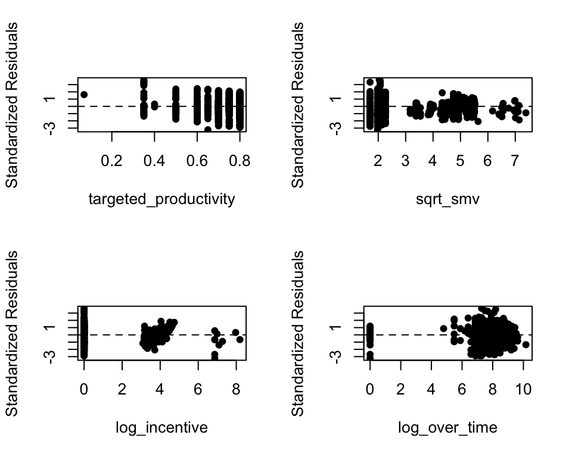

```r
par(mfrow = c(2, 2))

plot(rstandard(fit_lm) ~ targeted_productivity, data, ylab = "Standardized Residuals",
    pch = 16)
abline(h = 0, lty = 2)

plot(rstandard(fit_lm) ~ sqrt_smv, data, ylab = "Standardized Residuals",
    pch = 16)
abline(h = 0, lty = 2)

plot(rstandard(fit_lm) ~ log_incentive, data, ylab = "Standardized Residuals",
    pch = 16)
abline(h = 0, lty = 2)

plot(rstandard(fit_lm) ~ log_over_time, data, ylab = "Standardized Residuals",
    pch = 16)
abline(h = 0, lty = 2)
```

## Studentized Breusch-Pagan Test

```r
library(lmtest)
bptest(fit_lm)
```

```
##
##  studentized Breusch-Pagan test
##
## data:  fit_lm
## BP = 278.05, df = 9, p-value < 2.2e-16
```

Strongly reject the null hypothesis of homoscedasticity. The variance of the random error terms is nonconstant as a function of at least one of the quantitative covariates

## Brown-Forsythe Test

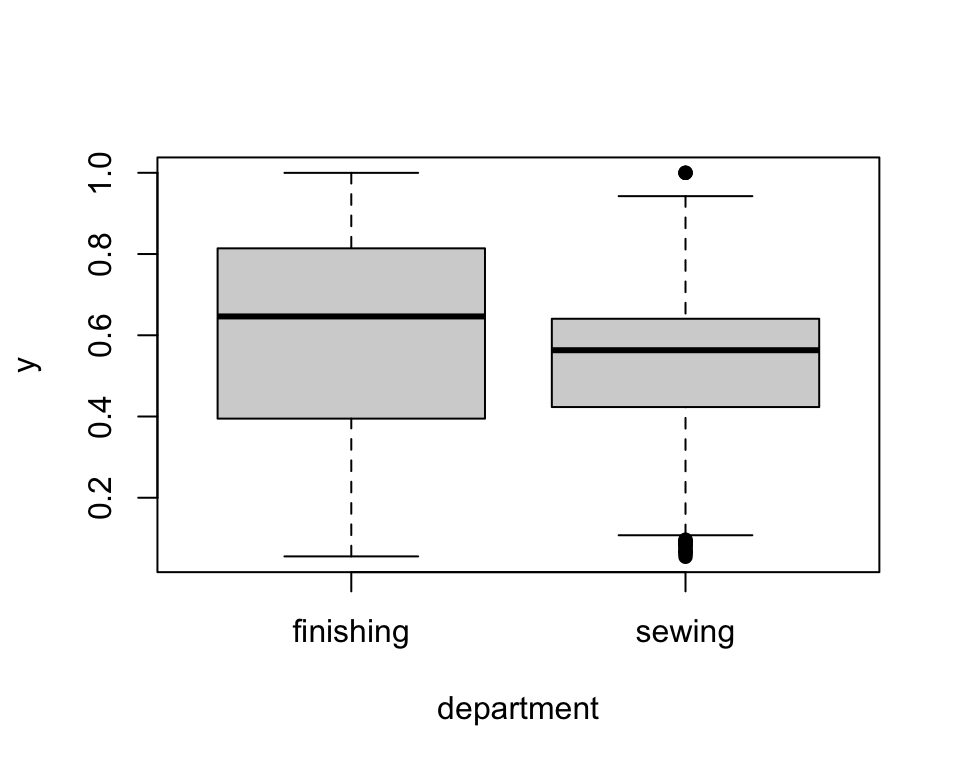

```r
boxplot(y ~ department, data, pch = 16)
```

```r
library(car)
leveneTest(y ~ department, data = data, center = median)
```

|  | Df | F value | Pr(>F) |
| --- | --- | --- | --- |
| group | 1 | 93.33007 | 2.742062e-21 |
|  | 1158 | NA | NA |

A Brown–Forsythe (median-based Levene) test also strongly rejects the null hypothesis of equal variances across groups, indicating substantial heteroscedasticity associated with the qualitative covariate.

## HC3 Robust Standard Errors

```r
library(sandwich)
library(lmtest)

coeftest(fit_lm, vcov = vcovHC(fit_lm, type = "HC3"))
```

```
##
## t test of coefficients:
##
##                          Estimate  Std. Error t value  Pr(>|t|)
## (Intercept)            0.11127463  0.07713558  1.4426  0.149410
## targeted_productivity  0.75459038  0.08497219  8.8804 < 2.2e-16 ***
## sqrt_smv              -0.07085894  0.01026088 -6.9057 8.245e-12 ***
## log_over_time          0.00378853  0.00441325  0.8584  0.390827
## log_incentive          0.02977324  0.00420696  7.0771 2.554e-12 ***
## log_idle_time          0.02112491  0.02795004  0.7558  0.449918
## log_idle_men          -0.06452096  0.02321264 -2.7796  0.005532 **
## no_of_style_change1   -0.04739887  0.01506351 -3.1466  0.001694 **
## no_of_style_change2   -0.06577442  0.02094810 -3.1399  0.001733 **
## no_of_workers          0.00203484  0.00068821  2.9567  0.003173 **
## ---
## Signif. codes:  0 '***' 0.001 '**' 0.01 '*' 0.05 '.' 0.1 ' ' 1
```

Given strong evidence of heteroscedasticity, heteroscedasticity-robust (HC3) standard errors were used for inference. The results indicate that targeted productivity, task complexity (SMV), incentives, idle workers, style changes, and team size remain statistically significant predictors of productivity, while overtime and idle time do not exhibit significant effects.

# 11: Heteroscedasticity Consistent Estimate

Fit a multiple linear model with all available quantitative covariates. Calculate a suitable heteroscedasticity-consistent estimate for the covariance matrix of the regression coefficients. How does it compare against the corresponding ordinary least squares estimate? Calculate heteroscedastisticity-consistent t test statistics and 95% CIs for the regression coefficients. How do they compare against the results yielded by the ordinary least squares method?

```r
fit <- lm(actual_productivity^2 ~ targeted_productivity + log_over_time +
    log_incentive + log_idle_time + sqrt_smv + log_idle_men + no_of_workers,
    data = data)

summary(fit)
```

```
##
## Call:
## lm(formula = actual_productivity^2 ~ targeted_productivity +
##     log_over_time + log_incentive + log_idle_time + sqrt_smv +
##     log_idle_men + no_of_workers, data = data)
##
## Residuals:
##      Min       1Q   Median       3Q      Max
## -0.61495 -0.09732 -0.00102  0.10843  0.71767
##
## Coefficients:
##                         Estimate Std. Error t value Pr(>|t|)
## (Intercept)            0.0865833  0.0561630   1.542   0.1234
## targeted_productivity  0.7818564  0.0599183  13.049  < 2e-16 ***
## log_over_time          0.0055127  0.0044667   1.234   0.2174
## log_incentive          0.0322517  0.0043677   7.384 2.93e-13 ***
## log_idle_time          0.0305631  0.0312765   0.977   0.3287
## sqrt_smv              -0.0737328  0.0116476  -6.330 3.50e-10 ***
## log_idle_men          -0.0731248  0.0291548  -2.508   0.0123 *
## no_of_workers          0.0017490  0.0008237   2.123   0.0339 *
## ---
## Signif. codes:  0 '***' 0.001 '**' 0.01 '*' 0.05 '.' 0.1 ' ' 1
##
## Residual standard error: 0.1944 on 1152 degrees of freedom
## Multiple R-squared:  0.2429, Adjusted R-squared:  0.2383
## F-statistic: 52.81 on 7 and 1152 DF,  p-value: < 2.2e-16
```

## OSL vs. HC Covariance Matrix

```r
vcov_OLS <- summary(fit)$sigma^2 * summary(fit)$cov.unscaled
vcov_OLS
```

```
##                         (Intercept) targeted_productivity log_over_time
## (Intercept)            3.154282e-03         -2.657065e-03 -1.261298e-04
## targeted_productivity -2.657065e-03          3.590202e-03 -2.170619e-06
## log_over_time         -1.261298e-04         -2.170619e-06  1.995164e-05
## log_incentive          2.386740e-05         -5.891504e-05  4.549154e-06
## log_idle_time          1.371665e-05          1.083392e-04 -1.403371e-05
## sqrt_smv              -1.356482e-04         -8.493565e-06 -6.769667e-06
## log_idle_men          -9.864962e-05         -8.776698e-05  2.782351e-05
## no_of_workers          7.486810e-06          5.963989e-06 -4.693779e-07
##                       log_incentive log_idle_time      sqrt_smv  log_idle_men
## (Intercept)            2.386740e-05  1.371665e-05 -1.356482e-04 -9.864962e-05
## targeted_productivity -5.891504e-05  1.083392e-04 -8.493565e-06 -8.776698e-05
## log_over_time          4.549154e-06 -1.403371e-05 -6.769667e-06  2.782351e-05
## log_incentive          1.907655e-05 -2.481481e-06 -4.364441e-06  1.825968e-05
## log_idle_time         -2.481481e-06  9.782186e-04  2.115120e-06 -7.736852e-04
## sqrt_smv              -4.364441e-06  2.115120e-06  1.356671e-04 -1.358243e-05
## log_idle_men           1.825968e-05 -7.736852e-04 -1.358243e-05  8.500020e-04
## no_of_workers         -1.135965e-06  4.821521e-07 -8.158462e-06 -1.659712e-06
##                       no_of_workers
## (Intercept)            7.486810e-06
## targeted_productivity  5.963989e-06
## log_over_time         -4.693779e-07
## log_incentive         -1.135965e-06
## log_idle_time          4.821521e-07
## sqrt_smv              -8.158462e-06
## log_idle_men          -1.659712e-06
## no_of_workers          6.784078e-07
```

```r
library(sandwich)
vcov_HC3 <- vcovHC(fit, type = "HC3")
vcov_HC3
```

```
##                         (Intercept) targeted_productivity log_over_time
## (Intercept)            5.785668e-03         -5.653644e-03 -1.356013e-04
## targeted_productivity -5.653644e-03          6.944351e-03  8.972561e-06
## log_over_time         -1.356013e-04          8.972561e-06  2.041503e-05
## log_incentive          1.171977e-04         -1.252456e-04 -2.194784e-06
## log_idle_time         -1.381527e-04          2.817783e-04 -1.125130e-05
## sqrt_smv              -1.455751e-04          1.142397e-04 -1.198395e-05
## log_idle_men           2.797205e-05         -1.992024e-04  2.010014e-05
## no_of_workers         -3.816151e-06          7.674396e-06  3.245336e-07
##                       log_incentive log_idle_time      sqrt_smv  log_idle_men
## (Intercept)            1.171977e-04 -1.381527e-04 -1.455751e-04  2.797205e-05
## targeted_productivity -1.252456e-04  2.817783e-04  1.142397e-04 -1.992024e-04
## log_over_time         -2.194784e-06 -1.125130e-05 -1.198395e-05  2.010014e-05
## log_incentive          1.648681e-05 -3.629359e-06 -4.205193e-06  1.278958e-05
## log_idle_time         -3.629359e-06  7.594619e-04  1.186305e-06 -5.163593e-04
## sqrt_smv              -4.205193e-06  1.186305e-06  9.452778e-05 -1.068779e-05
## log_idle_men           1.278958e-05 -5.163593e-04 -1.068779e-05  4.887920e-04
## no_of_workers         -8.508369e-07  6.747867e-07 -5.202333e-06 -1.066813e-06
##                       no_of_workers
## (Intercept)           -3.816151e-06
## targeted_productivity  7.674396e-06
## log_over_time          3.245336e-07
## log_incentive         -8.508369e-07
## log_idle_time          6.747867e-07
## sqrt_smv              -5.202333e-06
## log_idle_men          -1.066813e-06
## no_of_workers          4.536212e-07
```

```r
se_OLS <- sqrt(diag(vcov_OLS))
se_HC3 <- sqrt(diag(vcov_HC3))

cbind(SE_OLS = se_OLS, SE_HC3 = se_HC3, ratio = se_HC3/se_OLS)
```

```
##                             SE_OLS       SE_HC3     ratio
## (Intercept)           0.0561629941 0.0760635775 1.3543362
## targeted_productivity 0.0599182974 0.0833327698 1.3907733
## log_over_time         0.0044667257 0.0045182995 1.0115462
## log_incentive         0.0043676706 0.0040603957 0.9296479
## log_idle_time         0.0312764867 0.0275583362 0.8811199
## sqrt_smv              0.0116476216 0.0097225399 0.8347232
## log_idle_men          0.0291547936 0.0221086403 0.7583192
## no_of_workers         0.0008236551 0.0006735141 0.8177137
```

OLS predicted too small of an SE for the intercept and targeted_productivity, and accurately predicted SE for log_over_time. OLS was too conservative for the other coefficients.

## HC t-tests & 95% CIs

```r
ols_table <- summary(fit)$coefficients
ols_table
```

```
##                           Estimate   Std. Error    t value     Pr(>|t|)
## (Intercept)            0.086583286 0.0561629941  1.5416430 1.234350e-01
## targeted_productivity  0.781856354 0.0599182974 13.0487078 2.138742e-36
## log_over_time          0.005512734 0.0044667257  1.2341778 2.173884e-01
## log_incentive          0.032251686 0.0043676706  7.3841847 2.933781e-13
## log_idle_time          0.030563119 0.0312764867  0.9771916 3.286795e-01
## sqrt_smv              -0.073732792 0.0116476216 -6.3302874 3.498751e-10
## log_idle_men          -0.073124773 0.0291547936 -2.5081561 1.227291e-02
## no_of_workers          0.001749011 0.0008236551  2.1234749 3.392675e-02
```

```r
ols_ci <- confint(fit, level = 0.95)
ols_ci
```

```
##                               2.5 %       97.5 %
## (Intercept)           -0.0236099333  0.196776506
## targeted_productivity  0.6642951334  0.899417574
## log_over_time         -0.0032510956  0.014276563
## log_incentive          0.0236822057  0.040821167
## log_idle_time         -0.0308021420  0.091928379
## sqrt_smv              -0.0965857211 -0.050879863
## log_idle_men          -0.1303272182 -0.015922329
## no_of_workers          0.0001329787  0.003365043
```

```r
library(lmtest)

hc3_tests <- coeftest(fit, vcov. = vcov_HC3)
hc3_tests
```

```
##
## t test of coefficients:
##
##                          Estimate  Std. Error t value  Pr(>|t|)
## (Intercept)            0.08658329  0.07606358  1.1383 0.2552313
## targeted_productivity  0.78185635  0.08333277  9.3823 < 2.2e-16 ***
## log_over_time          0.00551273  0.00451830  1.2201 0.2226803
## log_incentive          0.03225169  0.00406040  7.9430 4.664e-15 ***
## log_idle_time          0.03056312  0.02755834  1.1090 0.2676472
## sqrt_smv              -0.07373279  0.00972254 -7.5837 6.893e-14 ***
## log_idle_men          -0.07312477  0.02210864 -3.3075 0.0009703 ***
## no_of_workers          0.00174901  0.00067351  2.5968 0.0095283 **
## ---
## Signif. codes:  0 '***' 0.001 '**' 0.01 '*' 0.05 '.' 0.1 ' ' 1
```

```r
hc3_ci <- confint(hc3_tests, level = 0.95)
hc3_ci
```

```
##                               2.5 %       97.5 %
## (Intercept)           -0.0626553830  0.235821956
## targeted_productivity  0.6183553445  0.945357363
## log_over_time         -0.0033522847  0.014377752
## log_incentive          0.0242850869  0.040218286
## log_idle_time         -0.0235070364  0.084633274
## sqrt_smv              -0.0928086618 -0.054656922
## log_idle_men          -0.1165024867 -0.029747060
## no_of_workers          0.0004275593  0.003070463
```

# 12: Iteratively Reweighted Least Squares

```r
fit <- lm(actual_productivity^2 ~ targeted_productivity + log_over_time +
    log_incentive + log_idle_time + sqrt_smv + log_idle_men + no_of_workers,
    data = data)

residuals <- fit$residuals
n <- nrow(data)

w <- rep(1, n)
err <- Inf
tol <- 1e-10
niter <- 0
maxiter <- 1000

while (err > tol & niter < maxiter) {
    aux <- lm(log(residuals^2) ~ log(targeted_productivity), data)
    err <- sum(abs(w - exp(-aux$fitted.values)))/sum(w)
    w <- exp(-aux$fitted.values)

    WLS <- lm(actual_productivity^2 ~ targeted_productivity + log_over_time +
        log_incentive + log_idle_time + sqrt_smv + log_idle_men + no_of_workers,
        data = data, weights = w)

    residuals <- WLS$residuals
    niter <- niter + 1
}

summary(aux)
```

```
##
## Call:
## lm(formula = log(residuals^2) ~ log(targeted_productivity), data = data)
##
## Residuals:
##     Min      1Q  Median      3Q     Max
## -15.393  -1.394   0.420   1.936   3.927
##
## Coefficients:
##                            Estimate Std. Error t value Pr(>|t|)
## (Intercept)                 -5.2737     0.1583 -33.316   <2e-16 ***
## log(targeted_productivity)  -0.8461     0.4238  -1.997   0.0461 *
## ---
## Signif. codes:  0 '***' 0.001 '**' 0.01 '*' 0.05 '.' 0.1 ' ' 1
##
## Residual standard error: 2.523 on 1158 degrees of freedom
## Multiple R-squared:  0.00343,    Adjusted R-squared:  0.00257
## F-statistic: 3.986 on 1 and 1158 DF,  p-value: 0.04611
```

```r
summary(WLS)
```

```
##
## Call:
## lm(formula = actual_productivity^2 ~ targeted_productivity +
##     log_over_time + log_incentive + log_idle_time + sqrt_smv +
##     log_idle_men + no_of_workers, data = data, weights = w)
##
## Weighted Residuals:
##     Min      1Q  Median      3Q     Max
## -7.1261 -1.1057 -0.0212  1.2896  6.8244
##
## Coefficients:
##                         Estimate Std. Error t value Pr(>|t|)
## (Intercept)            0.0076028  0.0613222   0.124  0.90135
## targeted_productivity  0.8816856  0.0686610  12.841  < 2e-16 ***
## log_over_time          0.0051482  0.0043308   1.189  0.23479
## log_incentive          0.0316380  0.0043384   7.293 5.64e-13 ***
## log_idle_time          0.0350055  0.0329473   1.062  0.28825
## sqrt_smv              -0.0744419  0.0115049  -6.470 1.44e-10 ***
## log_idle_men          -0.0784037  0.0296559  -2.644  0.00831 **
## no_of_workers          0.0020938  0.0008125   2.577  0.01009 *
## ---
## Signif. codes:  0 '***' 0.001 '**' 0.01 '*' 0.05 '.' 0.1 ' ' 1
##
## Residual standard error: 2.336 on 1152 degrees of freedom
## Multiple R-squared:  0.2337, Adjusted R-squared:  0.229
## F-statistic: 50.19 on 7 and 1152 DF,  p-value: < 2.2e-16
```

The auxiliary model results show a significant negative relationship between the squared residuals and targeted productivity, meaning that variance decreases as targeted productivity increases. Specifically, the variance is inversely proportional to targeted productivity raised to a power of approximately 0.85 — meaning the variance follows a decreasing power-law function of targeted productivity. This justifies using inverse-variance weighting in the iterative reweighted least squares procedure to correct for heteroscedasticity.

The auxiliary IRLS regression reveals a statistically significant relationship between the variance of the random error terms and targeted productivity, with residual variance decreasing as targeted productivity increases. This provides justification for the use of iteratively reweighted least squares. Using the optimal weights obtained from IRLS, a weighted least squares model was fit with all available quantitative covariates. Compared to ordinary least squares, the WLS covariance matrix yields different standard error estimates, with several coefficients exhibiting reduced uncertainty, indicating improved efficiency. The main conclusions remain consistent across methods: targeted productivity, log incentive, sqrt smv, log idle men, and number of workers remain statistically significant, while log over time and log idle time do not. Overall, WLS provides more reliable and efficient inference than OLS by explicitly modeling nonconstant error variance.

# 13: Multiple Comparisons

```r
library(lattice)
alpha = 0.05
Y = data$actual_productivity^2
data$date <- factor(data$date)
Q = data$date
n = length(Q)
K = length(levels(Q))
mu = aggregate(actual_productivity^2 ~ date, data, mean)[, 2]
sigma = sqrt(sum((Y - mu[Q])^2)/(n - K))
SE = sigma * sqrt(2 * K/n)
diff = outer(mu, mu, "-")
diff = diff[lower.tri(diff)]
lab = outer(levels(Q), levels(Q), function(x, y) {
    paste0(x, "-", y)
})
names(diff) = lab[lower.tri(lab)]

# Unadjusted CIs
CI = cbind(diff - qt(1 - alpha/2, n - K) * SE, diff + qt(1 - alpha/2,
    n - K) * SE)
colnames(CI) = c("Lower Bound", "Upper Bound")
print(CI)
```

```
##                         Lower Bound   Upper Bound
## 2015-01-03-2015-01-01 -0.0127381028  0.2602290686
## 2015-01-04-2015-01-01 -0.0413453425  0.2316218288
## 2015-01-05-2015-01-01 -0.0274147515  0.2455524198
## 2015-01-06-2015-01-01 -0.0117539119  0.2612132594
## 2015-01-07-2015-01-01 -0.0611334554  0.2118337159
## 2015-01-08-2015-01-01 -0.0594171184  0.2135500529
## 2015-01-10-2015-01-01 -0.0496485144  0.2233186569
## 2015-01-11-2015-01-01 -0.0873588667  0.1856083046
## 2015-01-12-2015-01-01 -0.0690525251  0.2039146462
## 2015-01-13-2015-01-01 -0.0725061017  0.2004610696
## 2015-01-14-2015-01-01 -0.1215794765  0.1513876948
## 2015-01-15-2015-01-01 -0.0735370939  0.1994300774
## 2015-01-17-2015-01-01 -0.1040326804  0.1689344909
## 2015-01-18-2015-01-01 -0.1869590577  0.0860081136
## 2015-01-19-2015-01-01 -0.1306841761  0.1422829952
## 2015-01-20-2015-01-01 -0.1938070773  0.0791600940
## 2015-01-21-2015-01-01 -0.1243632003  0.1486039710
## 2015-01-22-2015-01-01 -0.1882093539  0.0847578174
## 2015-01-24-2015-01-01 -0.0758934361  0.1970737353
## 2015-01-25-2015-01-01 -0.0382507145  0.2347164569
## 2015-01-26-2015-01-01 -0.0308118876  0.2421552837
## 2015-01-27-2015-01-01 -0.0649605145  0.2080066568
## 2015-01-28-2015-01-01 -0.1624110620  0.1105561094
## 2015-01-29-2015-01-01 -0.0342510220  0.2387161493
## 2015-01-31-2015-01-01  0.0801378407  0.3531050120
## 2015-02-01-2015-01-01 -0.0799760777  0.1929910936
## 2015-02-02-2015-01-01 -0.1501613710  0.1228058003
## 2015-02-03-2015-01-01 -0.0575697831  0.2153973882
## 2015-02-04-2015-01-01 -0.0693699389  0.2035972325
## 2015-02-05-2015-01-01 -0.0387677067  0.2341994646
## 2015-02-07-2015-01-01 -0.0941499325  0.1788172388
## 2015-02-08-2015-01-01 -0.0802129013  0.1927542700
## 2015-02-09-2015-01-01 -0.1130233475  0.1599438239
## 2015-02-10-2015-01-01 -0.0689984117  0.2039687596
## 2015-02-11-2015-01-01 -0.1096528939  0.1633142774
## 2015-02-12-2015-01-01 -0.2771343091 -0.0041671378
## 2015-02-14-2015-01-01 -0.1705584027  0.1024087687
## 2015-02-15-2015-01-01 -0.2578458680  0.0151213033
## 2015-02-16-2015-01-01 -0.1657049340  0.1072622374
```

[output cut: 1657 more lines]

```
## 2015-03-07-2015-03-05 -0.1834651601  0.0895020112
## 2015-03-08-2015-03-05 -0.1290417048  0.1439254665
## 2015-03-09-2015-03-05 -0.1503585994  0.1226085720
## 2015-03-10-2015-03-05 -0.1196753593  0.1532918120
## 2015-03-11-2015-03-05 -0.1633291112  0.1096380601
## 2015-03-08-2015-03-07 -0.0820601304  0.1909070409
## 2015-03-09-2015-03-07 -0.1033770249  0.1695901464
## 2015-03-10-2015-03-07 -0.0726937849  0.2002733864
## 2015-03-11-2015-03-07 -0.1163475368  0.1566196345
## 2015-03-09-2015-03-08 -0.1578004802  0.1151666911
## 2015-03-10-2015-03-08 -0.1271172402  0.1458499312
## 2015-03-11-2015-03-08 -0.1707709921  0.1021961793
## 2015-03-10-2015-03-09 -0.1058003456  0.1671668257
## 2015-03-11-2015-03-09 -0.1494540975  0.1235130738
## 2015-03-11-2015-03-10 -0.1801373376  0.0928298337
```

# Scheffé’s method

```r
Scheffe = cbind(diff - sqrt((K - 1) * qf(1 - alpha, K - 1, n - K)) *
    SE, diff + sqrt((K - 1) * qf(1 - alpha, K - 1, n - K)) * SE)
colnames(Scheffe) = c("Lower Bound", "Upper Bound")
print(Scheffe)
```

```
##                       Lower Bound Upper Bound
## 2015-01-03-2015-01-01  -0.4886061   0.7360971
## 2015-01-04-2015-01-01  -0.5172133   0.7074898
## 2015-01-05-2015-01-01  -0.5032827   0.7214204
## 2015-01-06-2015-01-01  -0.4876219   0.7370812
## 2015-01-07-2015-01-01  -0.5370014   0.6877017
## 2015-01-08-2015-01-01  -0.5352851   0.6894180
## 2015-01-10-2015-01-01  -0.5255165   0.6991866
## 2015-01-11-2015-01-01  -0.5632269   0.6614763
## 2015-01-12-2015-01-01  -0.5449205   0.6797826
## 2015-01-13-2015-01-01  -0.5483741   0.6763291
## 2015-01-14-2015-01-01  -0.5974475   0.6272557
## 2015-01-15-2015-01-01  -0.5494051   0.6752981
## 2015-01-17-2015-01-01  -0.5799007   0.6448025
## 2015-01-18-2015-01-01  -0.6628270   0.5618761
## 2015-01-19-2015-01-01  -0.6065522   0.6181510
## 2015-01-20-2015-01-01  -0.6696751   0.5550281
## 2015-01-21-2015-01-01  -0.6002312   0.6244720
## 2015-01-22-2015-01-01  -0.6640773   0.5606258
## 2015-01-24-2015-01-01  -0.5517614   0.6729417
## 2015-01-25-2015-01-01  -0.5141187   0.7105844
## 2015-01-26-2015-01-01  -0.5066799   0.7180233
## 2015-01-27-2015-01-01  -0.5408285   0.6838746
## 2015-01-28-2015-01-01  -0.6382790   0.5864241
## 2015-01-29-2015-01-01  -0.5101190   0.7145841
## 2015-01-31-2015-01-01  -0.3957301   0.8289730
## 2015-02-01-2015-01-01  -0.5558441   0.6688591
## 2015-02-02-2015-01-01  -0.6260294   0.5986738
## 2015-02-03-2015-01-01  -0.5334378   0.6912654
## 2015-02-04-2015-01-01  -0.5452379   0.6794652
## 2015-02-05-2015-01-01  -0.5146357   0.7100675
## 2015-02-07-2015-01-01  -0.5700179   0.6546852
## 2015-02-08-2015-01-01  -0.5560809   0.6686223
## 2015-02-09-2015-01-01  -0.5888913   0.6358118
## 2015-02-10-2015-01-01  -0.5448664   0.6798367
## 2015-02-11-2015-01-01  -0.5855209   0.6391823
## 2015-02-12-2015-01-01  -0.7530023   0.4717008
## 2015-02-14-2015-01-01  -0.6464264   0.5782768
## 2015-02-15-2015-01-01  -0.7337139   0.4909893
## 2015-02-16-2015-01-01  -0.6415729   0.5831302
```

[output cut: 1657 more lines]

```
## 2015-03-07-2015-03-05  -0.6593331   0.5653700
## 2015-03-08-2015-03-05  -0.6049097   0.6197935
## 2015-03-09-2015-03-05  -0.6262266   0.5984766
## 2015-03-10-2015-03-05  -0.5955433   0.6291598
## 2015-03-11-2015-03-05  -0.6391971   0.5855060
## 2015-03-08-2015-03-07  -0.5579281   0.6667750
## 2015-03-09-2015-03-07  -0.5792450   0.6454581
## 2015-03-10-2015-03-07  -0.5485618   0.6761414
## 2015-03-11-2015-03-07  -0.5922155   0.6324876
## 2015-03-09-2015-03-08  -0.6336685   0.5910347
## 2015-03-10-2015-03-08  -0.6029852   0.6217179
## 2015-03-11-2015-03-08  -0.6466390   0.5780642
## 2015-03-10-2015-03-09  -0.5816683   0.6430348
## 2015-03-11-2015-03-09  -0.6253221   0.5993811
## 2015-03-11-2015-03-10  -0.6560053   0.5686978
```

# Tukey’s HSD method

```r
Tukey = cbind(diff - qtukey(1 - alpha, K, n - K) * SE/sqrt(2), diff +
    qtukey(1 - alpha, K, n - K) * SE/sqrt(2))
colnames(Tukey) = c("Lower Bound", "Upper Bound")
print(Tukey)
```

```
##                        Lower Bound  Upper Bound
## 2015-01-03-2015-01-01 -0.160132167  0.407623133
## 2015-01-04-2015-01-01 -0.188739407  0.379015894
## 2015-01-05-2015-01-01 -0.174808816  0.392946485
## 2015-01-06-2015-01-01 -0.159147977  0.408607324
## 2015-01-07-2015-01-01 -0.208527520  0.359227781
## 2015-01-08-2015-01-01 -0.206811183  0.360944118
## 2015-01-10-2015-01-01 -0.197042579  0.370712722
## 2015-01-11-2015-01-01 -0.234752931  0.333002369
## 2015-01-12-2015-01-01 -0.216446590  0.351308711
## 2015-01-13-2015-01-01 -0.219900166  0.347855134
## 2015-01-14-2015-01-01 -0.268973541  0.298781760
## 2015-01-15-2015-01-01 -0.220931159  0.346824142
## 2015-01-17-2015-01-01 -0.251426745  0.316328556
## 2015-01-18-2015-01-01 -0.334353122  0.233402178
## 2015-01-19-2015-01-01 -0.278078241  0.289677060
## 2015-01-20-2015-01-01 -0.341201142  0.226554159
## 2015-01-21-2015-01-01 -0.271757265  0.295998036
## 2015-01-22-2015-01-01 -0.335603419  0.232151882
## 2015-01-24-2015-01-01 -0.223287501  0.344467800
## 2015-01-25-2015-01-01 -0.185644779  0.382110522
## 2015-01-26-2015-01-01 -0.178205952  0.389549348
## 2015-01-27-2015-01-01 -0.212354579  0.355400722
## 2015-01-28-2015-01-01 -0.309805127  0.257950174
## 2015-01-29-2015-01-01 -0.181645087  0.386110214
## 2015-01-31-2015-01-01 -0.067256224  0.500499077
## 2015-02-01-2015-01-01 -0.227370142  0.340385158
## 2015-02-02-2015-01-01 -0.297555436  0.270199865
## 2015-02-03-2015-01-01 -0.204963848  0.362791453
## 2015-02-04-2015-01-01 -0.216764004  0.350991297
## 2015-02-05-2015-01-01 -0.186161771  0.381593529
## 2015-02-07-2015-01-01 -0.241543997  0.326211304
## 2015-02-08-2015-01-01 -0.227606966  0.340148335
## 2015-02-09-2015-01-01 -0.260417412  0.307337889
## 2015-02-10-2015-01-01 -0.216392476  0.351362824
## 2015-02-11-2015-01-01 -0.257046959  0.310708342
## 2015-02-12-2015-01-01 -0.424528374  0.143226927
## 2015-02-14-2015-01-01 -0.317952467  0.249802833
## 2015-02-15-2015-01-01 -0.405239933  0.162515368
## 2015-02-16-2015-01-01 -0.313098999  0.254656302
```

[output cut: 1657 more lines]

```
## 2015-03-07-2015-03-05 -0.330859225  0.236896076
## 2015-03-08-2015-03-05 -0.276435770  0.291319531
## 2015-03-09-2015-03-05 -0.297752664  0.270002637
## 2015-03-10-2015-03-05 -0.267069424  0.300685877
## 2015-03-11-2015-03-05 -0.310723176  0.257032125
## 2015-03-08-2015-03-07 -0.229454195  0.338301106
## 2015-03-09-2015-03-07 -0.250771090  0.316984211
## 2015-03-10-2015-03-07 -0.220087850  0.347667451
## 2015-03-11-2015-03-07 -0.263741602  0.304013699
## 2015-03-09-2015-03-08 -0.305194545  0.262560756
## 2015-03-10-2015-03-08 -0.274511305  0.293243996
## 2015-03-11-2015-03-08 -0.318165057  0.249590244
## 2015-03-10-2015-03-09 -0.253194410  0.314560890
## 2015-03-11-2015-03-09 -0.296848162  0.270907139
## 2015-03-11-2015-03-10 -0.327531402  0.240223898
```

```r
TukeyHSD(aov(actual_productivity^2 ~ date, data))
```

```
##   Tukey multiple comparisons of means
##     95% family-wise confidence level
##
## Fit: aov(formula = actual_productivity^2 ~ date, data = data)
##
## $date
##                                diff           lwr          upr     p adj
## 2015-01-03-2015-01-01  1.237455e-01 -0.1580686316  0.405559597 0.9999906
## 2015-01-04-2015-01-01  9.513824e-02 -0.1866758714  0.376952358 1.0000000
## 2015-01-05-2015-01-01  1.090688e-01 -0.1696863677  0.387824036 0.9999998
## 2015-01-06-2015-01-01  1.247297e-01 -0.1570844408  0.406543788 0.9999880
## 2015-01-07-2015-01-01  7.535013e-02 -0.2034050715  0.354105332 1.0000000
## 2015-01-08-2015-01-01  7.706647e-02 -0.2016887345  0.355821669 1.0000000
## 2015-01-10-2015-01-01  8.683507e-02 -0.1919201306  0.365590273 1.0000000
## 2015-01-11-2015-01-01  4.912472e-02 -0.2268079487  0.325057387 1.0000000
## 2015-01-12-2015-01-01  6.743106e-02 -0.2085016071  0.343363728 1.0000000
## 2015-01-13-2015-01-01  6.397748e-02 -0.2147777178  0.342732686 1.0000000
## 2015-01-14-2015-01-01  1.490411e-02 -0.2669100054  0.296718224 1.0000000
## 2015-01-15-2015-01-01  6.294649e-02 -0.2258270439  0.351720027 1.0000000
## 2015-01-17-2015-01-01  3.245091e-02 -0.2493632093  0.314265020 1.0000000
## 2015-01-18-2015-01-01 -5.047547e-02 -0.3392490078  0.238298064 1.0000000
## 2015-01-19-2015-01-01  5.799410e-03 -0.2829741261  0.294572945 1.0000000
## 2015-01-20-2015-01-01 -5.732349e-02 -0.3708219031  0.256174920 1.0000000
## 2015-01-21-2015-01-01  1.212039e-02 -0.2766531503  0.300893921 1.0000000
## 2015-01-22-2015-01-01 -5.172577e-02 -0.3304809700  0.227029434 1.0000000
## 2015-01-24-2015-01-01  6.059015e-02 -0.2153425181  0.336522817 1.0000000
## 2015-01-25-2015-01-01  9.823287e-02 -0.1835812434  0.380046986 1.0000000
## 2015-01-26-2015-01-01  1.056717e-01 -0.1870851090  0.398428505 1.0000000
## 2015-01-27-2015-01-01  7.152307e-02 -0.2172504646  0.360296607 1.0000000
## 2015-01-28-2015-01-01 -2.592748e-02 -0.3147010120  0.262846059 1.0000000
## 2015-01-29-2015-01-01  1.022326e-01 -0.1865409720  0.391006099 1.0000000
## 2015-01-31-2015-01-01  2.166214e-01 -0.0621337755  0.495376628 0.5601702
## 2015-02-01-2015-01-01  5.650751e-02 -0.2454990846  0.358514100 1.0000000
## 2015-02-02-2015-01-01 -1.367779e-02 -0.3064345924  0.279079022 1.0000000
## 2015-02-03-2015-01-01  7.891380e-02 -0.2182317142  0.376059319 1.0000000
## 2015-02-04-2015-01-01  6.711365e-02 -0.2300318700  0.364259164 1.0000000
## 2015-02-05-2015-01-01  9.771588e-02 -0.2042907136  0.399722472 1.0000000
## 2015-02-07-2015-01-01  4.233365e-02 -0.2548118637  0.339479170 1.0000000
## 2015-02-08-2015-01-01  5.627068e-02 -0.2364861227  0.349027491 1.0000000
## 2015-02-09-2015-01-01  2.346024e-02 -0.2736852786  0.320605755 1.0000000
```

[output cut: 1663 more lines]

```
## 2015-03-07-2015-03-05 -4.698157e-02 -0.3357551101  0.241791961 1.0000000
## 2015-03-08-2015-03-05  7.441881e-03 -0.2713133210  0.286197083 1.0000000
## 2015-03-09-2015-03-05 -1.387501e-02 -0.2926302155  0.264880188 1.0000000
## 2015-03-10-2015-03-05  1.680823e-02 -0.2591244414  0.292740894 1.0000000
## 2015-03-11-2015-03-05 -2.684553e-02 -0.3001652659  0.246474215 1.0000000
## 2015-03-08-2015-03-07  5.442346e-02 -0.2243317466  0.333178657 1.0000000
## 2015-03-09-2015-03-07  3.310656e-02 -0.2456486411  0.311861763 1.0000000
## 2015-03-10-2015-03-07  6.378980e-02 -0.2121428669  0.339722468 1.0000000
## 2015-03-11-2015-03-07  2.013605e-02 -0.2531836915  0.293455789 1.0000000
## 2015-03-09-2015-03-08 -2.131689e-02 -0.2896800257  0.247046237 1.0000000
## 2015-03-10-2015-03-08  9.366346e-03 -0.2560637672  0.274796458 1.0000000
## 2015-03-11-2015-03-08 -3.428741e-02 -0.2970001546  0.228425342 1.0000000
## 2015-03-10-2015-03-09  3.068324e-02 -0.2347468727  0.296113353 1.0000000
## 2015-03-11-2015-03-09 -1.297051e-02 -0.2756832601  0.249742236 1.0000000
## 2015-03-11-2015-03-10 -4.365375e-02 -0.3033696787  0.216062175 1.0000000
```

# 14: Multiple Linear Model

```r
# Get p-values from the model
fit = lm(actual_productivity^2 ~ targeted_productivity + log_over_time +
    log_incentive + log_idle_time + sqrt_smv + log_idle_men + no_of_workers +
    team + department + date, data)

pvalues = summary(fit)$coefficients[-1, 4]
m = length(pvalues)
alpha = 0.05

# 1. Bonferroni test
Bonf = min(pvalues)
cat("Bonferroni test rejects H0:", Bonf < alpha/m, "\n")
```

```
## Bonferroni test rejects H0: TRUE
```

```r
# 2. Fisher's combination test
Fisher = -2 * sum(log(pvalues))
cat("Fisher test rejects H0:", Fisher > qchisq(1 - alpha, 2 * m), "\n")
```

```
## Fisher test rejects H0: TRUE
```

```r
# 3. Simes test
Simes = sum(pvalues[order(pvalues)] <= (1:m) * alpha/m)
cat("Simes test rejects H0:", Simes > 0, "\n")
```

```
## Simes test rejects H0: TRUE
```

Bonferroni is the most conservative method, controlling the family-wise error rate by testing each p-value against α/m. It assumes independence but remains valid (though overly strict) under positive dependence.

Fisher’s combination test aggregates p-values using −2∑log(p), which follows a chi-square distribution under independence. It is more powerful than Bonferroni when multiple weak effects exist but requires independent p-values.

Simes test is less conservative than Bonferroni but more powerful; it rejects if at least one ordered p-value is ≤ (i)α/m. It is valid under positive dependence and is often used in genomics and high-dimensional testing.

All three rejected H₀ here, suggesting strong evidence of at least one significant predictor. Given that p-valus come from a multiple regression with correlated predictors, Bonferroni remains valid but conservative, Fisher’s independence assumption may be violated, and Simes is likely the most appropriate due to its robustness under positive dependence.

# 15: Multiple Testing Methods - FWER AND FDR Control at 5% level

```r
# Apply multiple testing methods

pvalues = summary(fit)$coefficients[-1, 4]
m = length(pvalues)
alpha = 0.05

# Holm-Bonferroni (controls FWER)
HB = p.adjust(pvalues, "holm")
sum(HB < alpha)
```

```
## [1] 10
```

```r
# Benjamini-Hochberg (controls FDR)
BH = p.adjust(pvalues, "BH")
sum(BH < alpha)
```

```
## [1] 13
```

```r
# Benjamini-Yekutieli (controls FDR under any dependence)
BY = p.adjust(pvalues, "BY")
sum(BY < alpha)
```

```
## [1] 10
```

```r
# Unadjusted (for comparison)
sum(pvalues < alpha)
```

```
## [1] 14
```

The Holm-Bonferroni procedure controls FWER, so it’s overly conservative resulting in only 10 rejections. The Benjamini-Hochberg procedure controls FDR, so it’s generally more powerful resulting in 13 rejections. However, the Benjamini-Hochberg procedure is only valid in the absence of any negative dependence among the tests being performed. The Benjamini-Yekutieli procedure still controls FDR while offering an adjustment which is valid under any form of dependence, so it’s more conservative and results in 10 rejections. Discounting the multiple testing problem would lead to 14 rejections many of which would likely be false. Benjamini-Hochberg is the most powerful method here, detecting 3 more significant effects than Holm-Bonferroni. Benjamini-Yekutieli ends up with the same number of rejections as Holm-Bonferroni even though it controls FDR instead of FWER, which shows the adjustment for dependence structure makes it much more conservative.

# 16: Final Model Specification and Inference Strategy

Based on analyses from problems 1-15, the final model is a **mixed-effects model**:

```
actual_productivity² ~ targeted_productivity + log_over_time + log_incentive +
                       log_idle_time + sqrt_smv + log_idle_men + no_of_workers +
                       (1|team) + (1|department) + (1|date)
```

## Model Components

**Response Transformation (Problem 4)**

Use actual_productivity². Box-Cox analysis indicated λ ≈ 2.0 (95% CI: [1.7, 2.3]).

**Covariate Transformations (Problem 4)**

- log_over_time = log(over_time + 1)
- log_incentive = log(incentive + 1)
- log_idle_time = log(idle_time + 1)
- sqrt_smv = sqrt(smv)
- log_idle_men = log(idle_men + 1)
- targeted_productivity, no_of_workers: no transformation

**Fixed Effects**

All quantitative covariates: targeted_productivity, log_over_time, log_incentive, log_idle_time, sqrt_smv, log_idle_men, no_of_workers.

**Random Effects (Problem 9)**

Random intercepts for team, department, and date. ICC analysis showed: - Department: 42.09% of total variation - Team: 3.03% of total variation - Date: 2.57% of total variation - Residual: 52.32% of total variation

This accounts for clustering—observations from the same team/department/date are correlated.

## Why Mixed-Effects Model?

1. **Clustering**: Observations within teams/departments/dates are correlated, violating independence.
2. **Heteroscedasticity (Problems 10, 11, 12)**: Breusch-Pagan test rejected homoscedasticity (p < 2.2e-16). Random effects absorb 47.68% of variation, reducing residual heteroscedasticity.
3. **Parsimony**: Captures team-level variation (Problem 8 interactions) through random intercepts rather than 24+ interaction parameters.

## Inference Strategy

**1. Fixed Effects Testing (Problem 9)**

Use likelihood ratio tests with REML=FALSE:

```r
full = lmer(y ~ targeted_productivity + log_over_time + log_incentive +
            log_idle_time + sqrt_smv + log_idle_men + no_of_workers +
            (1|team) + (1|department) + (1|date), data, REML=FALSE)

reduced = lmer(y ~ [exclude one covariate] + (1|team) + (1|department) + (1|date),
               data, REML=FALSE)

LR = -2 * (logLik(reduced) - logLik(full))
pvalue = pchisq(LR, df=1, lower.tail=FALSE)
```

Problem 9 results: - **Significant (p < 0.05)**: targeted_productivity, log_incentive, sqrt_smv, no_of_workers - **Not significant**: log_over_time, log_idle_time, log_idle_men

**2. Multiple Testing Correction (Problem 14)**

Apply Benjamini-Hochberg (FDR control) or Holm-Bonferroni (FWER control):

```r
pvalues = [extract from LR tests]
adjusted_p = p.adjust(pvalues, method="BH")
```

**3. Global Hypothesis Testing (Problem 14)**

Test H₀: all β = 0 using three methods:

```r
# Bonferroni
Bonf = min(pvalues) < alpha/m

# Fisher's combination
Fisher = -2 * sum(log(pvalues)) > qchisq(1 - alpha, 2*m)

# Simes
Simes = sum(pvalues[order(pvalues)] <= (1:m) * alpha/m) > 0
```

All three rejected H₀, confirming at least one significant effect exists.

**4. Confidence Intervals**

Use profile likelihood for 95% CIs:

```r
confint(full, method="profile", level=0.95)
```

Profile likelihood intervals account for uncertainty in variance components, unlike Wald intervals.

**5. Model Diagnostics**

- Check Q-Q plot for residual normality (Problem 4)
- Verify no patterns in residuals vs fitted values
- Cross-validate on train/validation/test split (Problem 5)

## Additional Considerations

**Problem 11 (HC3 Robust SE)**: If fitting as linear model, use HC3 heteroscedasticity-consistent standard errors. However, this doesn’t account for clustering, so mixed-effects model is preferred.

**Problem 12 (WLS)**: IRLS showed variance depends on targeted_productivity. Mixed-effects random intercepts already absorb this, so additional weighting unnecessary.

**Problem 13 (Multiple Comparisons)**: Tukey’s HSD found no significant pairwise differences across dates, justifying date as random effect rather than fixed.

## Conclusion

The mixed-effects model addresses: - **Non-normality**: Response transformation (λ = 2) - **Non-linearity**: Covariate transformations - **Heteroscedasticity**: Random effects absorb variation - **Clustering**: Random intercepts for team/department/date - **Multiple testing**: Benjamini-Hochberg or Holm-Bonferroni correction

Inference uses likelihood ratio tests with FDR/FWER control and profile likelihood CIs. This ensures valid conclusions about productivity factors while accounting for data structure and assumption violations.